# Project: Identify Customer Segments

In this project, you will apply unsupervised learning techniques to identify segments of the population that form the core customer base for a mail-order sales company in Germany. These segments can then be used to direct marketing campaigns towards audiences that will have the highest expected rate of returns. The data that you will use has been provided by our partners at Bertelsmann Arvato Analytics, and represents a real-life data science task.

This notebook will help you complete this task by providing a framework within which you will perform your analysis steps. In each step of the project, you will see some text describing the subtask that you will perform, followed by one or more code cells for you to complete your work. **Feel free to add additional code and markdown cells as you go along so that you can explore everything in precise chunks.** The code cells provided in the base template will outline only the major tasks, and will usually not be enough to cover all of the minor tasks that comprise it.

It should be noted that while there will be precise guidelines on how you should handle certain tasks in the project, there will also be places where an exact specification is not provided. **There will be times in the project where you will need to make and justify your own decisions on how to treat the data.** These are places where there may not be only one way to handle the data. In real-life tasks, there may be many valid ways to approach an analysis task. One of the most important things you can do is clearly document your approach so that other scientists can understand the decisions you've made.

At the end of most sections, there will be a Markdown cell labeled **Discussion**. In these cells, you will report your findings for the completed section, as well as document the decisions that you made in your approach to each subtask. **Your project will be evaluated not just on the code used to complete the tasks outlined, but also your communication about your observations and conclusions at each stage.**

```python
# import libraries here; add more as necessary
import numpy as np
import pandas as pd
import matplotlib.pyplot as plt
import seaborn as sns
from sklearn.preprocessing import Imputer
from sklearn.base import TransformerMixin
from sklearn.preprocessing import StandardScaler
from sklearn.decomposition import PCA
from sklearn.cluster import KMeans

# magic word for producing visualizations in notebook
%matplotlib inline
```

### Step 0: Load the Data

Each row of the demographics files represents a single person, but also includes information outside of individuals, including information about their household, building, and neighborhood. You will use this information to cluster the general population into groups with similar demographic properties. Then, you will see how the people in the customers dataset fit into those created clusters. The hope here is that certain clusters are over-represented in the customers data, as compared to the general population; those over-represented clusters will be assumed to be part of the core userbase. This information can then be used for further applications, such as targeting for a marketing campaign.

To start off with, load in the demographics data for the general population into a pandas DataFrame, and do the same for the feature attributes summary. Note for all of the `.csv` data files in this project: they're semicolon (`;`) delimited, so you'll need an additional argument in your [`read_csv()`](https://pandas.pydata.org/pandas-docs/stable/generated/pandas.read_csv.html) call to read in the data properly. Also, considering the size of the main dataset, it may take some time for it to load completely.

Once the dataset is loaded, it's recommended that you take a little bit of time just browsing the general structure of the dataset and feature summary file. You'll be getting deep into the innards of the cleaning in the first major step of the project, so gaining some general familiarity can help you get your bearings.

```python
# Load in the general demographics data.
azdias = pd.read_csv('Udacity_AZDIAS_Subset.csv',delimiter=';')

# Load in the feature summary file.
feat_info = pd.read_csv('AZDIAS_Feature_Summary.csv',delimiter=';')
```

```python
# Check the structure of the data after it's loaded (e.g. print the number of
# rows and columns, print the first few rows).
print('shape of demorgraphic data for the general population is ',azdias.shape)

print('First few rows of demorgraphic data')

print(azdias[:10])
```

```
shape of demorgraphic data for the general population is  (891221, 85)
First few rows of demorgraphic data
   AGER_TYP  ALTERSKATEGORIE_GROB  ANREDE_KZ  CJT_GESAMTTYP  \
0        -1                     2          1            2.0
1        -1                     1          2            5.0
2        -1                     3          2            3.0
3         2                     4          2            2.0
4        -1                     3          1            5.0
5         3                     1          2            2.0
6        -1                     2          2            5.0
7        -1                     1          1            3.0
8        -1                     3          1            3.0
9        -1                     3          2            4.0

   FINANZ_MINIMALIST  FINANZ_SPARER  FINANZ_VORSORGER  FINANZ_ANLEGER  \
```

[output cut: 48 more lines]

```python
azdias.describe()
```

|  | AGER_TYP | ALTERSKATEGORIE_GROB | ANREDE_KZ | CJT_GESAMTTYP | FINANZ_MINIMALIST | FINANZ_SPARER | FINANZ_VORSORGER | FINANZ_ANLEGER | FINANZ_UNAUFFAELLIGER | FINANZ_HAUSBAUER | ... | PLZ8_ANTG1 | PLZ8_ANTG2 | PLZ8_ANTG3 | PLZ8_ANTG4 | PLZ8_BAUMAX | PLZ8_HHZ | PLZ8_GBZ | ARBEIT | ORTSGR_KLS9 | RELAT_AB |
| --- | --- | --- | --- | --- | --- | --- | --- | --- | --- | --- | --- | --- | --- | --- | --- | --- | --- | --- | --- | --- | --- |
| count | 891221.000000 | 891221.000000 | 891221.000000 | 886367.000000 | 891221.000000 | 891221.000000 | 891221.000000 | 891221.000000 | 891221.000000 | 891221.000000 | ... | 774706.000000 | 774706.000000 | 774706.000000 | 774706.000000 | 774706.000000 | 774706.000000 | 774706.000000 | 794005.000000 | 794005.000000 | 794005.00000 |
| mean | -0.358435 | 2.777398 | 1.522098 | 3.632838 | 3.074528 | 2.821039 | 3.401106 | 3.033328 | 2.874167 | 3.075121 | ... | 2.253330 | 2.801858 | 1.595426 | 0.699166 | 1.943913 | 3.612821 | 3.381087 | 3.167854 | 5.293002 | 3.07222 |
| std | 1.198724 | 1.068775 | 0.499512 | 1.595021 | 1.321055 | 1.464749 | 1.322134 | 1.529603 | 1.486731 | 1.353248 | ... | 0.972008 | 0.920309 | 0.986736 | 0.727137 | 1.459654 | 0.973967 | 1.111598 | 1.002376 | 2.303739 | 1.36298 |
| min | -1.000000 | 1.000000 | 1.000000 | 1.000000 | 1.000000 | 1.000000 | 1.000000 | 1.000000 | 1.000000 | 1.000000 | ... | 0.000000 | 0.000000 | 0.000000 | 0.000000 | 1.000000 | 1.000000 | 1.000000 | 1.000000 | 0.000000 | 1.00000 |
| 25% | -1.000000 | 2.000000 | 1.000000 | 2.000000 | 2.000000 | 1.000000 | 3.000000 | 2.000000 | 2.000000 | 2.000000 | ... | 1.000000 | 2.000000 | 1.000000 | 0.000000 | 1.000000 | 3.000000 | 3.000000 | 3.000000 | 4.000000 | 2.00000 |
| 50% | -1.000000 | 3.000000 | 2.000000 | 4.000000 | 3.000000 | 3.000000 | 3.000000 | 3.000000 | 3.000000 | 3.000000 | ... | 2.000000 | 3.000000 | 2.000000 | 1.000000 | 1.000000 | 4.000000 | 3.000000 | 3.000000 | 5.000000 | 3.00000 |
| 75% | -1.000000 | 4.000000 | 2.000000 | 5.000000 | 4.000000 | 4.000000 | 5.000000 | 5.000000 | 4.000000 | 4.000000 | ... | 3.000000 | 3.000000 | 2.000000 | 1.000000 | 3.000000 | 4.000000 | 4.000000 | 4.000000 | 7.000000 | 4.00000 |
| max | 3.000000 | 9.000000 | 2.000000 | 6.000000 | 5.000000 | 5.000000 | 5.000000 | 5.000000 | 5.000000 | 5.000000 | ... | 4.000000 | 4.000000 | 3.000000 | 2.000000 | 5.000000 | 5.000000 | 5.000000 | 9.000000 | 9.000000 | 9.00000 |

8 rows × 81 columns

```python
print('shape of Feature Summary is ',feat_info.shape)

print('Data in Feature Summary')

feat_info
```

```
shape of Feature Summary is  (85, 4)
Data in Feature Summary
```

|  | attribute | information_level | type | missing_or_unknown |
| --- | --- | --- | --- | --- |
| 0 | AGER_TYP | person | categorical | [-1,0] |
| 1 | ALTERSKATEGORIE_GROB | person | ordinal | [-1,0,9] |
| 2 | ANREDE_KZ | person | categorical | [-1,0] |
| 3 | CJT_GESAMTTYP | person | categorical | [0] |
| 4 | FINANZ_MINIMALIST | person | ordinal | [-1] |
| 5 | FINANZ_SPARER | person | ordinal | [-1] |
| 6 | FINANZ_VORSORGER | person | ordinal | [-1] |
| 7 | FINANZ_ANLEGER | person | ordinal | [-1] |
| 8 | FINANZ_UNAUFFAELLIGER | person | ordinal | [-1] |
| 9 | FINANZ_HAUSBAUER | person | ordinal | [-1] |
| 10 | FINANZTYP | person | categorical | [-1] |
| 11 | GEBURTSJAHR | person | numeric | [0] |
| 12 | GFK_URLAUBERTYP | person | categorical | [] |
| 13 | GREEN_AVANTGARDE | person | categorical | [] |
| 14 | HEALTH_TYP | person | ordinal | [-1,0] |
| 15 | LP_LEBENSPHASE_FEIN | person | mixed | [0] |
| 16 | LP_LEBENSPHASE_GROB | person | mixed | [0] |
| 17 | LP_FAMILIE_FEIN | person | categorical | [0] |
| 18 | LP_FAMILIE_GROB | person | categorical | [0] |
| 19 | LP_STATUS_FEIN | person | categorical | [0] |
| 20 | LP_STATUS_GROB | person | categorical | [0] |
| 21 | NATIONALITAET_KZ | person | categorical | [-1,0] |
| 22 | PRAEGENDE_JUGENDJAHRE | person | mixed | [-1,0] |
| 23 | RETOURTYP_BK_S | person | ordinal | [0] |
| 24 | SEMIO_SOZ | person | ordinal | [-1,9] |
| 25 | SEMIO_FAM | person | ordinal | [-1,9] |
| 26 | SEMIO_REL | person | ordinal | [-1,9] |
| 27 | SEMIO_MAT | person | ordinal | [-1,9] |
| 28 | SEMIO_VERT | person | ordinal | [-1,9] |
| 29 | SEMIO_LUST | person | ordinal | [-1,9] |
| ... | ... | ... | ... | ... |
| 55 | OST_WEST_KZ | building | categorical | [-1] |
| 56 | WOHNLAGE | building | mixed | [-1] |
| 57 | CAMEO_DEUG_2015 | microcell_rr4 | categorical | [-1,X] |
| 58 | CAMEO_DEU_2015 | microcell_rr4 | categorical | [XX] |
| 59 | CAMEO_INTL_2015 | microcell_rr4 | mixed | [-1,XX] |
| 60 | KBA05_ANTG1 | microcell_rr3 | ordinal | [-1] |
| 61 | KBA05_ANTG2 | microcell_rr3 | ordinal | [-1] |
| 62 | KBA05_ANTG3 | microcell_rr3 | ordinal | [-1] |
| 63 | KBA05_ANTG4 | microcell_rr3 | ordinal | [-1] |
| 64 | KBA05_BAUMAX | microcell_rr3 | mixed | [-1,0] |
| 65 | KBA05_GBZ | microcell_rr3 | ordinal | [-1,0] |
| 66 | BALLRAUM | postcode | ordinal | [-1] |
| 67 | EWDICHTE | postcode | ordinal | [-1] |
| 68 | INNENSTADT | postcode | ordinal | [-1] |
| 69 | GEBAEUDETYP_RASTER | region_rr1 | ordinal | [] |
| 70 | KKK | region_rr1 | ordinal | [-1,0] |
| 71 | MOBI_REGIO | region_rr1 | ordinal | [] |
| 72 | ONLINE_AFFINITAET | region_rr1 | ordinal | [] |
| 73 | REGIOTYP | region_rr1 | ordinal | [-1,0] |
| 74 | KBA13_ANZAHL_PKW | macrocell_plz8 | numeric | [] |
| 75 | PLZ8_ANTG1 | macrocell_plz8 | ordinal | [-1] |
| 76 | PLZ8_ANTG2 | macrocell_plz8 | ordinal | [-1] |
| 77 | PLZ8_ANTG3 | macrocell_plz8 | ordinal | [-1] |
| 78 | PLZ8_ANTG4 | macrocell_plz8 | ordinal | [-1] |
| 79 | PLZ8_BAUMAX | macrocell_plz8 | mixed | [-1,0] |
| 80 | PLZ8_HHZ | macrocell_plz8 | ordinal | [-1] |
| 81 | PLZ8_GBZ | macrocell_plz8 | ordinal | [-1] |
| 82 | ARBEIT | community | ordinal | [-1,9] |
| 83 | ORTSGR_KLS9 | community | ordinal | [-1,0] |
| 84 | RELAT_AB | community | ordinal | [-1,9] |

85 rows × 4 columns

> **Tip**: Add additional cells to keep everything in reasonably-sized chunks! Keyboard shortcut `esc --> a` (press escape to enter command mode, then press the 'A' key) adds a new cell before the active cell, and `esc --> b` adds a new cell after the active cell. If you need to convert an active cell to a markdown cell, use `esc --> m` and to convert to a code cell, use `esc --> y`.

## Step 1: Preprocessing

### Step 1.1: Assess Missing Data

The feature summary file contains a summary of properties for each demographics data column. You will use this file to help you make cleaning decisions during this stage of the project. First of all, you should assess the demographics data in terms of missing data. Pay attention to the following points as you perform your analysis, and take notes on what you observe. Make sure that you fill in the **Discussion** cell with your findings and decisions at the end of each step that has one!

#### Step 1.1.1: Convert Missing Value Codes to NaNs

The fourth column of the feature attributes summary (loaded in above as `feat_info`) documents the codes from the data dictionary that indicate missing or unknown data. While the file encodes this as a list (e.g. `[-1,0]`), this will get read in as a string object. You'll need to do a little bit of parsing to make use of it to identify and clean the data. Convert data that matches a 'missing' or 'unknown' value code into a numpy NaN value. You might want to see how much data takes on a 'missing' or 'unknown' code, and how much data is naturally missing, as a point of interest.

**As one more reminder, you are encouraged to add additional cells to break up your analysis into manageable chunks.**

```python
# Identify naturally missing values (NaNs)

naturally_missing = azdias.isnull().sum()
naturally_missing
```

```
AGER_TYP                      0
ALTERSKATEGORIE_GROB          0
ANREDE_KZ                     0
CJT_GESAMTTYP              4854
FINANZ_MINIMALIST             0
FINANZ_SPARER                 0
FINANZ_VORSORGER              0
FINANZ_ANLEGER                0
FINANZ_UNAUFFAELLIGER         0
FINANZ_HAUSBAUER              0
FINANZTYP                     0
GEBURTSJAHR                   0
GFK_URLAUBERTYP            4854
GREEN_AVANTGARDE              0
HEALTH_TYP                    0
LP_LEBENSPHASE_FEIN        4854
LP_LEBENSPHASE_GROB        4854
LP_FAMILIE_FEIN            4854
LP_FAMILIE_GROB            4854
LP_STATUS_FEIN             4854
LP_STATUS_GROB             4854
NATIONALITAET_KZ              0
PRAEGENDE_JUGENDJAHRE         0
RETOURTYP_BK_S             4854
SEMIO_SOZ                     0
SEMIO_FAM                     0
SEMIO_REL                     0
SEMIO_MAT                     0
SEMIO_VERT                    0
SEMIO_LUST                    0
                          ...
OST_WEST_KZ               93148
WOHNLAGE                  93148
CAMEO_DEUG_2015           98979
CAMEO_DEU_2015            98979
CAMEO_INTL_2015           98979
KBA05_ANTG1              133324
KBA05_ANTG2              133324
KBA05_ANTG3              133324
KBA05_ANTG4              133324
KBA05_BAUMAX             133324
KBA05_GBZ                133324
BALLRAUM                  93740
EWDICHTE                  93740
INNENSTADT                93740
GEBAEUDETYP_RASTER        93155
KKK                      121196
MOBI_REGIO               133324
ONLINE_AFFINITAET          4854
REGIOTYP                 121196
KBA13_ANZAHL_PKW         105800
PLZ8_ANTG1               116515
PLZ8_ANTG2               116515
PLZ8_ANTG3               116515
PLZ8_ANTG4               116515
PLZ8_BAUMAX              116515
PLZ8_HHZ                 116515
PLZ8_GBZ                 116515
ARBEIT                    97216
ORTSGR_KLS9               97216
RELAT_AB                  97216
Length: 85, dtype: int64
```

```python
# eliminating from the dataframe of feat_info 'X' and 'XX' as both will be eliminated from azdias below

eliminate_char = ['\[', '\]']

mis_val = feat_info ['missing_or_unknown'].replace (to_replace = eliminate_char, value = '', regex = True)

display (mis_val)
```

```
0       -1,0
1     -1,0,9
2       -1,0
3          0
4         -1
5         -1
6         -1
7         -1
8         -1
9         -1
10        -1
11         0
12
13
14      -1,0
```

[output cut: 47 more lines]

```python
#creating new list miss_val that will contain str as a list
miss_val = []

for item in range (len (mis_val)):
    miss_val.append (mis_val [item].split (','))

display (miss_val)
```

```
[['-1', '0'],
 ['-1', '0', '9'],
 ['-1', '0'],
 ['0'],
 ['-1'],
 ['-1'],
 ['-1'],
 ['-1'],
 ['-1'],
 ['-1'],
 ['-1'],
 ['0'],
 [''],
 [''],
 ['-1', '0'],
 ['0'],
 ['0'],
 ['0'],
 ['0'],
 ['0'],
 ['0'],
 ['-1', '0'],
 ['-1', '0'],
 ['0'],
 ['-1', '9'],
 ['-1', '9'],
 ['-1', '9'],
 ['-1', '9'],
 ['-1', '9'],
 ['-1', '9'],
 ['-1', '9'],
 ['-1', '9'],
 ['-1', '9'],
 ['-1', '9'],
 ['-1', '9'],
 ['-1', '9'],
 ['-1', '9'],
 ['-1', '9'],
 ['-1'],
 ['-1'],
```

[output cut: 30 more lines]

```
 ['-1', '0'],
 [''],
 [''],
 ['-1', '0'],
 [''],
 ['-1'],
 ['-1'],
 ['-1'],
 ['-1'],
 ['-1', '0'],
 ['-1'],
 ['-1'],
 ['-1', '9'],
 ['-1', '0'],
 ['-1', '9']]
```

```python
#converting values of miss_val into float where applicable

for item in range (len (miss_val)):
    for j in range (len (miss_val [item])):
        #float cannot convert '', 'X' or 'XX' to float so have to skip it. However we will need it in replacing
        if (miss_val [item] [j] == '' or miss_val [item] [j] == 'X' or miss_val [item] [j] == 'XX'):
            pass
        else:
            miss_val [item] [j] = float (miss_val [item] [j])

display (miss_val)
```

```
[[-1.0, 0.0],
 [-1.0, 0.0, 9.0],
 [-1.0, 0.0],
 [0.0],
 [-1.0],
 [-1.0],
 [-1.0],
 [-1.0],
 [-1.0],
 [-1.0],
 [-1.0],
 [0.0],
 [''],
 [''],
 [-1.0, 0.0],
 [0.0],
 [0.0],
 [0.0],
 [0.0],
 [0.0],
 [0.0],
 [-1.0, 0.0],
 [-1.0, 0.0],
 [0.0],
 [-1.0, 9.0],
 [-1.0, 9.0],
 [-1.0, 9.0],
 [-1.0, 9.0],
 [-1.0, 9.0],
 [-1.0, 9.0],
 [-1.0, 9.0],
 [-1.0, 9.0],
 [-1.0, 9.0],
 [-1.0, 9.0],
 [-1.0, 9.0],
 [-1.0, 9.0],
 [-1.0, 9.0],
 [-1.0, 9.0],
 [-1.0],
 [-1.0],
```

[output cut: 30 more lines]

```
 [-1.0, 0.0],
 [''],
 [''],
 [-1.0, 0.0],
 [''],
 [-1.0],
 [-1.0],
 [-1.0],
 [-1.0],
 [-1.0, 0.0],
 [-1.0],
 [-1.0],
 [-1.0, 9.0],
 [-1.0, 0.0],
 [-1.0, 9.0]]
```

```python
#filling missing or unknown values with NaN as per the created list miss_val

for item in range (len (miss_val)):
    column_name = feat_info.iloc [item] ['attribute'] #saving column name
    azdias [column_name].replace (to_replace = miss_val [item], value = np.NaN, regex = True, inplace = True)
```

```python
# Now let's take a look to the result

display (azdias.head (n=10))
```

|  | AGER_TYP | ALTERSKATEGORIE_GROB | ANREDE_KZ | CJT_GESAMTTYP | FINANZ_MINIMALIST | FINANZ_SPARER | FINANZ_VORSORGER | FINANZ_ANLEGER | FINANZ_UNAUFFAELLIGER | FINANZ_HAUSBAUER | ... | PLZ8_ANTG1 | PLZ8_ANTG2 | PLZ8_ANTG3 | PLZ8_ANTG4 | PLZ8_BAUMAX | PLZ8_HHZ | PLZ8_GBZ | ARBEIT | ORTSGR_KLS9 | RELAT_AB |
| --- | --- | --- | --- | --- | --- | --- | --- | --- | --- | --- | --- | --- | --- | --- | --- | --- | --- | --- | --- | --- | --- |
| 0 | NaN | 2 | 1 | 2.0 | 3 | 4 | 3 | 5 | 5 | 3 | ... | NaN | NaN | NaN | NaN | NaN | NaN | NaN | NaN | NaN | NaN |
| 1 | NaN | 1 | 2 | 5.0 | 1 | 5 | 2 | 5 | 4 | 5 | ... | 2.0 | 3.0 | 2.0 | 1.0 | 1.0 | 5.0 | 4.0 | 3.0 | 5.0 | 4.0 |
| 2 | NaN | 3 | 2 | 3.0 | 1 | 4 | 1 | 2 | 3 | 5 | ... | 3.0 | 3.0 | 1.0 | 0.0 | 1.0 | 4.0 | 4.0 | 3.0 | 5.0 | 2.0 |
| 3 | 2.0 | 4 | 2 | 2.0 | 4 | 2 | 5 | 2 | 1 | 2 | ... | 2.0 | 2.0 | 2.0 | 0.0 | 1.0 | 3.0 | 4.0 | 2.0 | 3.0 | 3.0 |
| 4 | NaN | 3 | 1 | 5.0 | 4 | 3 | 4 | 1 | 3 | 2 | ... | 2.0 | 4.0 | 2.0 | 1.0 | 2.0 | 3.0 | 3.0 | 4.0 | 6.0 | 5.0 |
| 5 | 3.0 | 1 | 2 | 2.0 | 3 | 1 | 5 | 2 | 2 | 5 | ... | 2.0 | 3.0 | 1.0 | 1.0 | 1.0 | 5.0 | 5.0 | 2.0 | 3.0 | 3.0 |
| 6 | NaN | 2 | 2 | 5.0 | 1 | 5 | 1 | 5 | 4 | 3 | ... | 3.0 | 3.0 | 1.0 | 0.0 | 1.0 | 5.0 | 5.0 | 4.0 | 6.0 | 3.0 |
| 7 | NaN | 1 | 1 | 3.0 | 3 | 3 | 4 | 1 | 3 | 2 | ... | 3.0 | 3.0 | 1.0 | 0.0 | 1.0 | 4.0 | 4.0 | 2.0 | 5.0 | 2.0 |
| 8 | NaN | 3 | 1 | 3.0 | 4 | 4 | 2 | 4 | 2 | 2 | ... | 2.0 | 3.0 | 2.0 | 1.0 | 1.0 | 3.0 | 3.0 | 2.0 | 4.0 | 3.0 |
| 9 | NaN | 3 | 2 | 4.0 | 2 | 4 | 2 | 3 | 5 | 4 | ... | 2.0 | 3.0 | 2.0 | 1.0 | 1.0 | 3.0 | 3.0 | 2.0 | 3.0 | 1.0 |

10 rows × 85 columns

#### Step 1.1.2: Assess Missing Data in Each Column

How much missing data is present in each column? There are a few columns that are outliers in terms of the proportion of values that are missing. You will want to use matplotlib's [`hist()`](https://matplotlib.org/api/_as_gen/matplotlib.pyplot.hist.html) function to visualize the distribution of missing value counts to find these columns. Identify and document these columns. While some of these columns might have justifications for keeping or re-encoding the data, for this project you should just remove them from the dataframe. (Feel free to make remarks about these outlier columns in the discussion, however!)

For the remaining features, are there any patterns in which columns have, or share, missing data?

```python
# Perform an assessment of how much missing data there is in each column of the
# dataset.

updated_missing = azdias.isnull().sum()
display(updated_missing)
```

```
AGER_TYP                 685843
ALTERSKATEGORIE_GROB       2881
ANREDE_KZ                     0
CJT_GESAMTTYP              4854
FINANZ_MINIMALIST             0
FINANZ_SPARER                 0
FINANZ_VORSORGER              0
FINANZ_ANLEGER                0
FINANZ_UNAUFFAELLIGER         0
FINANZ_HAUSBAUER              0
FINANZTYP                     0
GEBURTSJAHR              392318
GFK_URLAUBERTYP            4854
GREEN_AVANTGARDE              0
HEALTH_TYP               111196
LP_LEBENSPHASE_FEIN       97632
LP_LEBENSPHASE_GROB       94572
LP_FAMILIE_FEIN           77792
LP_FAMILIE_GROB           77792
LP_STATUS_FEIN             4854
LP_STATUS_GROB             4854
NATIONALITAET_KZ         108315
PRAEGENDE_JUGENDJAHRE    108164
RETOURTYP_BK_S             4854
SEMIO_SOZ                     0
SEMIO_FAM                     0
SEMIO_REL                     0
SEMIO_MAT                     0
SEMIO_VERT                    0
SEMIO_LUST                    0
                          ...
OST_WEST_KZ               93148
WOHNLAGE                  93148
CAMEO_DEUG_2015           99352
CAMEO_DEU_2015            99352
CAMEO_INTL_2015           99352
KBA05_ANTG1              133324
KBA05_ANTG2              133324
KBA05_ANTG3              133324
KBA05_ANTG4              133324
KBA05_BAUMAX             476524
KBA05_GBZ                133324
BALLRAUM                  93740
EWDICHTE                  93740
INNENSTADT                93740
GEBAEUDETYP_RASTER        93155
KKK                      158064
MOBI_REGIO               133324
ONLINE_AFFINITAET          4854
REGIOTYP                 158064
KBA13_ANZAHL_PKW         105800
PLZ8_ANTG1               116515
PLZ8_ANTG2               116515
PLZ8_ANTG3               116515
PLZ8_ANTG4               116515
PLZ8_BAUMAX              116515
PLZ8_HHZ                 116515
PLZ8_GBZ                 116515
ARBEIT                    97375
ORTSGR_KLS9               97274
RELAT_AB                  97375
Length: 85, dtype: int64
```

```
array([[<matplotlib.axes._subplots.AxesSubplot object at 0x7f1f01345780>]], dtype=object)
```

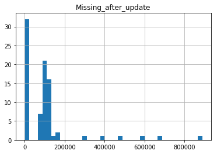

```python
# Investigate patterns in the amount of missing data in each column.

nan_count = pd.DataFrame(updated_missing, columns = ['Missing_after_update'])
nan_count.hist(bins=40)
```

```python
number_of_rec = azdias.shape [0]

# Proportion of missing values
prop_msval = (nan_count*100)/number_of_rec

# Identify features which are missing more than 10% of the data
prop_msval2 = prop_msval[prop_msval['Missing_after_update'] > 10.0]
display (prop_msval2)

print('{0} Features are missing more then 10% of data'.format(prop_msval2.shape[0]))
```

|  | Missing_after_update |
| --- | --- |
| AGER_TYP | 76.955435 |
| GEBURTSJAHR | 44.020282 |
| HEALTH_TYP | 12.476816 |
| LP_LEBENSPHASE_FEIN | 10.954859 |
| LP_LEBENSPHASE_GROB | 10.611509 |
| NATIONALITAET_KZ | 12.153551 |
| PRAEGENDE_JUGENDJAHRE | 12.136608 |
| SHOPPER_TYP | 12.476816 |
| TITEL_KZ | 99.757636 |
| VERS_TYP | 12.476816 |
| ALTER_HH | 34.813699 |
| KK_KUNDENTYP | 65.596749 |
| W_KEIT_KIND_HH | 16.605084 |
| ANZ_HAUSHALTE_AKTIV | 11.176913 |
| ANZ_HH_TITEL | 10.884842 |
| GEBAEUDETYP | 10.451729 |
| MIN_GEBAEUDEJAHR | 10.451729 |
| OST_WEST_KZ | 10.451729 |
| WOHNLAGE | 10.451729 |
| CAMEO_DEUG_2015 | 11.147852 |
| CAMEO_DEU_2015 | 11.147852 |
| CAMEO_INTL_2015 | 11.147852 |
| KBA05_ANTG1 | 14.959701 |
| KBA05_ANTG2 | 14.959701 |
| KBA05_ANTG3 | 14.959701 |
| KBA05_ANTG4 | 14.959701 |
| KBA05_BAUMAX | 53.468668 |
| KBA05_GBZ | 14.959701 |
| BALLRAUM | 10.518154 |
| EWDICHTE | 10.518154 |
| INNENSTADT | 10.518154 |
| GEBAEUDETYP_RASTER | 10.452514 |
| KKK | 17.735668 |
| MOBI_REGIO | 14.959701 |
| REGIOTYP | 17.735668 |
| KBA13_ANZAHL_PKW | 11.871354 |
| PLZ8_ANTG1 | 13.073637 |
| PLZ8_ANTG2 | 13.073637 |
| PLZ8_ANTG3 | 13.073637 |
| PLZ8_ANTG4 | 13.073637 |
| PLZ8_BAUMAX | 13.073637 |
| PLZ8_HHZ | 13.073637 |
| PLZ8_GBZ | 13.073637 |
| ARBEIT | 10.926022 |
| ORTSGR_KLS9 | 10.914689 |
| RELAT_AB | 10.926022 |

```
46 Features are missing more then 10% of data
```

```
<function matplotlib.pyplot.show(*args, **kw)>
```

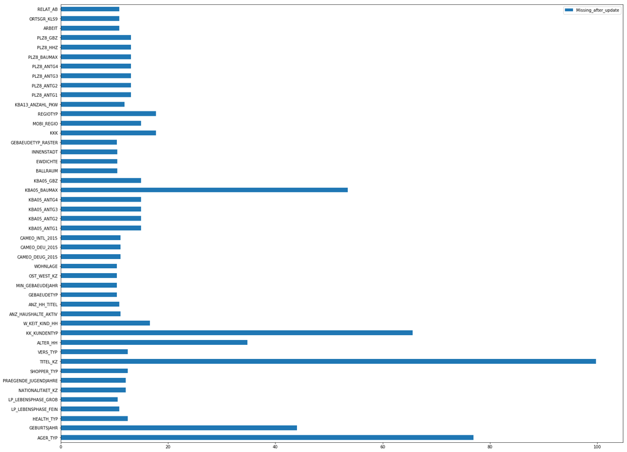

```python
prop_msval2.plot(kind='barh', figsize= (25,20) )
plt.show
```

46 features of the dataset contains NaN in more than 10% of data. According to the bar chart above, among these 46 features, 6 of them can be considered as outliers.

Namely, AGER_TYP 76.95%, GEBURTSJAHR 44.02%, TITEL_KZ 99.75%, ALTER_HH 34.81%, KK_KUNDENTYP 65.59% and KBA05_BAUMAX 53.46%

Hence these 6 features will be eliminated from the dataset.

```python
# Remove the outlier columns from the dataset. (You'll perform other data
# engineering tasks such as re-encoding and imputation later.)

azdias_new = azdias.drop(columns=['AGER_TYP','GEBURTSJAHR','TITEL_KZ','ALTER_HH','KK_KUNDENTYP','KBA05_BAUMAX'])

azdias_new.shape
```

```
(891221, 79)
```

#### Discussion 1.1.2: Assess Missing Data in Each Column

I removed the features which had more than 20% of data missing (having NaN). Namely;

```
1. AGER_TYP
2. GEBURTSJAHR
3. TITEL_KZ
4. ALTER_HH
5. KK_KUNDENTY
6. KBA05_BAUMAX
```

**Patterns in missing values:**

1) It seems that the 3 community level features, ARBEIT, ORTSGR_KLS9 and RELAT_AB have quite similar rate of missing values.

2) Except for KBA13_ANZAHL_PKW, all other PLZ8 macro-cell features have a similar rate of 13.073637%. Hence, we could use one of those instead of those 7 PLZ8 features (PLZ8_ANTG1, PLZ8_ANTG2, PLZ8_ANTG3, PLZ8_ANTG4, PLZ8_BAUMAX, PLZ8_HHZ and PLZ8_GBZ).

3) Except for KBA05_BAUMAX (identified outlier), all other RR3 micro-cell features have a similar rate of 14.959701%.

4) All Postcode-level features, namely; BALLRAUM, EWDICHTE and INNENSTADT have a missing rate of 10.518154%. Hence, it will be possible to used one feature, instead of all 3.

#### Step 1.1.3: Assess Missing Data in Each Row

Now, you'll perform a similar assessment for the rows of the dataset. How much data is missing in each row? As with the columns, you should see some groups of points that have a very different numbers of missing values. Divide the data into two subsets: one for data points that are above some threshold for missing values, and a second subset for points below that threshold.

In order to know what to do with the outlier rows, we should see if the distribution of data values on columns that are not missing data (or are missing very little data) are similar or different between the two groups. Select at least five of these columns and compare the distribution of values.

- You can use seaborn's [`countplot()`](https://seaborn.pydata.org/generated/seaborn.countplot.html) function to create a bar chart of code frequencies and matplotlib's [`subplot()`](https://matplotlib.org/api/_as_gen/matplotlib.pyplot.subplot.html) function to put bar charts for the two subplots side by side.
- To reduce repeated code, you might want to write a function that can perform this comparison, taking as one of its arguments a column to be compared.

Depending on what you observe in your comparison, this will have implications on how you approach your conclusions later in the analysis. If the distributions of non-missing features look similar between the data with many missing values and the data with few or no missing values, then we could argue that simply dropping those points from the analysis won't present a major issue. On the other hand, if the data with many missing values looks very different from the data with few or no missing values, then we should make a note on those data as special. We'll revisit these data later on. **Either way, you should continue your analysis for now using just the subset of the data with few or no missing values.**

```python
# How much data is missing in each row of the dataset?
miss_rows = pd.DataFrame(azdias_new.isnull().sum(axis=1), columns=['missing_in_rows'] )
miss_rows[:10]
```

|  | missing_in_rows |
| --- | --- |
| 0 | 43 |
| 1 | 0 |
| 2 | 0 |
| 3 | 7 |
| 4 | 0 |
| 5 | 0 |
| 6 | 0 |
| 7 | 0 |
| 8 | 0 |
| 9 | 0 |

```
array([[<matplotlib.axes._subplots.AxesSubplot object at 0x7f9522eb1860>]], dtype=object)
```

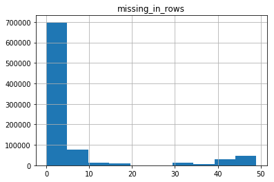

```python
miss_rows.hist()
```

From a quick glance of the above histogram, it is visible that data can be splitted into 2 by, '20 or more features missing data' versus 'less than 20 features missing data'.

```python
#first let us add a column to the dataset, which will contain number of values missing in each row.

azdias_new2 = azdias_new.join (miss_rows)
display (azdias_new2.head (n=10))
```

|  | ALTERSKATEGORIE_GROB | ANREDE_KZ | CJT_GESAMTTYP | FINANZ_MINIMALIST | FINANZ_SPARER | FINANZ_VORSORGER | FINANZ_ANLEGER | FINANZ_UNAUFFAELLIGER | FINANZ_HAUSBAUER | FINANZTYP | ... | PLZ8_ANTG2 | PLZ8_ANTG3 | PLZ8_ANTG4 | PLZ8_BAUMAX | PLZ8_HHZ | PLZ8_GBZ | ARBEIT | ORTSGR_KLS9 | RELAT_AB | missing_in_rows |
| --- | --- | --- | --- | --- | --- | --- | --- | --- | --- | --- | --- | --- | --- | --- | --- | --- | --- | --- | --- | --- | --- |
| 0 | 2.0 | 1.0 | 2.0 | 3.0 | 4.0 | 3.0 | 5.0 | 5.0 | 3.0 | 4.0 | ... | NaN | NaN | NaN | NaN | NaN | NaN | NaN | NaN | NaN | 43 |
| 1 | 1.0 | 2.0 | 5.0 | 1.0 | 5.0 | 2.0 | 5.0 | 4.0 | 5.0 | 1.0 | ... | 3.0 | 2.0 | 1.0 | 1.0 | 5.0 | 4.0 | 3.0 | 5.0 | 4.0 | 0 |
| 2 | 3.0 | 2.0 | 3.0 | 1.0 | 4.0 | 1.0 | 2.0 | 3.0 | 5.0 | 1.0 | ... | 3.0 | 1.0 | 0.0 | 1.0 | 4.0 | 4.0 | 3.0 | 5.0 | 2.0 | 0 |
| 3 | 4.0 | 2.0 | 2.0 | 4.0 | 2.0 | 5.0 | 2.0 | 1.0 | 2.0 | 6.0 | ... | 2.0 | 2.0 | 0.0 | 1.0 | 3.0 | 4.0 | 2.0 | 3.0 | 3.0 | 7 |
| 4 | 3.0 | 1.0 | 5.0 | 4.0 | 3.0 | 4.0 | 1.0 | 3.0 | 2.0 | 5.0 | ... | 4.0 | 2.0 | 1.0 | 2.0 | 3.0 | 3.0 | 4.0 | 6.0 | 5.0 | 0 |
| 5 | 1.0 | 2.0 | 2.0 | 3.0 | 1.0 | 5.0 | 2.0 | 2.0 | 5.0 | 2.0 | ... | 3.0 | 1.0 | 1.0 | 1.0 | 5.0 | 5.0 | 2.0 | 3.0 | 3.0 | 0 |
| 6 | 2.0 | 2.0 | 5.0 | 1.0 | 5.0 | 1.0 | 5.0 | 4.0 | 3.0 | 4.0 | ... | 3.0 | 1.0 | 0.0 | 1.0 | 5.0 | 5.0 | 4.0 | 6.0 | 3.0 | 0 |
| 7 | 1.0 | 1.0 | 3.0 | 3.0 | 3.0 | 4.0 | 1.0 | 3.0 | 2.0 | 5.0 | ... | 3.0 | 1.0 | 0.0 | 1.0 | 4.0 | 4.0 | 2.0 | 5.0 | 2.0 | 0 |
| 8 | 3.0 | 1.0 | 3.0 | 4.0 | 4.0 | 2.0 | 4.0 | 2.0 | 2.0 | 6.0 | ... | 3.0 | 2.0 | 1.0 | 1.0 | 3.0 | 3.0 | 2.0 | 4.0 | 3.0 | 0 |
| 9 | 3.0 | 2.0 | 4.0 | 2.0 | 4.0 | 2.0 | 3.0 | 5.0 | 4.0 | 1.0 | ... | 3.0 | 2.0 | 1.0 | 1.0 | 3.0 | 3.0 | 2.0 | 3.0 | 1.0 | 0 |

10 rows × 80 columns

```python
# Write code to divide the data into two subsets based on the number of missing
# values in each row.

azdias_new3= azdias_new2[azdias_new2['missing_in_rows']>=20]
azdias_new4= azdias_new2[azdias_new2['missing_in_rows']<20]
```

```python
# Compare the distribution of values for at least five columns where there are
# no or few missing values, between the two subsets.

def compare(ds1, ds2, col):
    fig, ax = plt.subplots(1,2)
    sns.countplot(ds1[col],ax=ax[0])
    sns.countplot(ds2[col],ax=ax[1])
    plt.subplots_adjust(wspace= 0.5)
    fig.show()
    return
```

#### azdias_new4 contains the rows which have less number of missing values

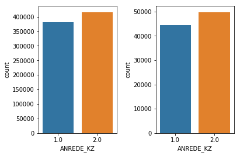

```python
compare(azdias_new4, azdias_new3, 'ANREDE_KZ')
```

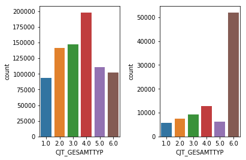

```python
compare(azdias_new4, azdias_new3, 'CJT_GESAMTTYP')
```

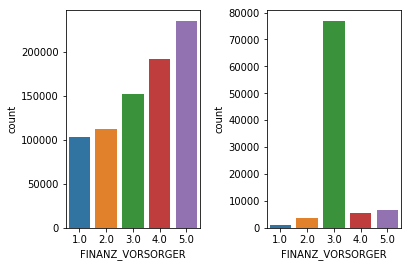

```python
compare(azdias_new4, azdias_new3, 'FINANZ_VORSORGER')
```

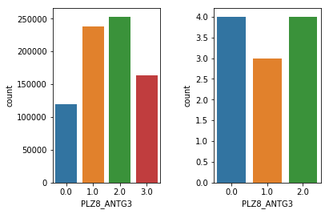

```python
compare(azdias_new4, azdias_new3, 'PLZ8_ANTG3')
```

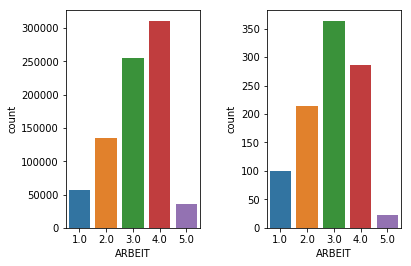

```python
compare(azdias_new4, azdias_new3, 'ARBEIT')
```

#### Discussion 1.1.3: Assess Missing Data in Each Row

Five features were compared and according to the graphs, clear differences can be seen with 4 of the features, except for ANREDE_KZ, which is Gender. Hence, I believe majority of data with lot of missing values, will be qualitatively different from data with few or no missing values.

Further, in Data Science one important factor is that our results would heavily depend upon the quality of input data. Thus, garbage in, garbage out.

### Step 1.2: Select and Re-Encode Features

Checking for missing data isn't the only way in which you can prepare a dataset for analysis. Since the unsupervised learning techniques to be used will only work on data that is encoded numerically, you need to make a few encoding changes or additional assumptions to be able to make progress. In addition, while almost all of the values in the dataset are encoded using numbers, not all of them represent numeric values. Check the third column of the feature summary (`feat_info`) for a summary of types of measurement.

- For numeric and interval data, these features can be kept without changes.
- Most of the variables in the dataset are ordinal in nature. While ordinal values may technically be non-linear in spacing, make the simplifying assumption that the ordinal variables can be treated as being interval in nature (that is, kept without any changes).
- Special handling may be necessary for the remaining two variable types: categorical, and 'mixed'.

In the first two parts of this sub-step, you will perform an investigation of the categorical and mixed-type features and make a decision on each of them, whether you will keep, drop, or re-encode each. Then, in the last part, you will create a new data frame with only the selected and engineered columns.

Data wrangling is often the trickiest part of the data analysis process, and there's a lot of it to be done here. But stick with it: once you're done with this step, you'll be ready to get to the machine learning parts of the project!

```python
# removing dropped features from feat_info as well
feat_info_idx = feat_info.isin(['AGER_TYP','GEBURTSJAHR','TITEL_KZ','ALTER_HH','KK_KUNDENTYP','KBA05_BAUMAX'])

feat_info_new = feat_info.drop (feat_info_idx [feat_info_idx.attribute == True].index)
feat_info_new.shape
```

```
(79, 4)
```

```python
# How many features are there of each data type?

feat_info_new.groupby(by="type").size()
```

```
type
categorical    18
mixed           6
numeric         6
ordinal        49
dtype: int64
```

#### Step 1.2.1: Re-Encode Categorical Features

For categorical data, you would ordinarily need to encode the levels as dummy variables. Depending on the number of categories, perform one of the following:

- For binary (two-level) categoricals that take numeric values, you can keep them without needing to do anything.
- There is one binary variable that takes on non-numeric values. For this one, you need to re-encode the values as numbers or create a dummy variable.
- For multi-level categoricals (three or more values), you can choose to encode the values using multiple dummy variables (e.g. via [OneHotEncoder](http://scikit-learn.org/stable/modules/generated/sklearn.preprocessing.OneHotEncoder.html)), or (to keep things straightforward) just drop them from the analysis. As always, document your choices in the Discussion section.

```python
feat_info_cat = feat_info_new[feat_info_new['type']=='categorical']
feat_info_cat
```

|  | attribute | information_level | type | missing_or_unknown |
| --- | --- | --- | --- | --- |
| 2 | ANREDE_KZ | person | categorical | [-1,0] |
| 3 | CJT_GESAMTTYP | person | categorical | [0] |
| 10 | FINANZTYP | person | categorical | [-1] |
| 12 | GFK_URLAUBERTYP | person | categorical | [] |
| 13 | GREEN_AVANTGARDE | person | categorical | [] |
| 17 | LP_FAMILIE_FEIN | person | categorical | [0] |
| 18 | LP_FAMILIE_GROB | person | categorical | [0] |
| 19 | LP_STATUS_FEIN | person | categorical | [0] |
| 20 | LP_STATUS_GROB | person | categorical | [0] |
| 21 | NATIONALITAET_KZ | person | categorical | [-1,0] |
| 38 | SHOPPER_TYP | person | categorical | [-1] |
| 39 | SOHO_KZ | person | categorical | [-1] |
| 41 | VERS_TYP | person | categorical | [-1] |
| 42 | ZABEOTYP | person | categorical | [-1,9] |
| 52 | GEBAEUDETYP | building | categorical | [-1,0] |
| 55 | OST_WEST_KZ | building | categorical | [-1] |
| 57 | CAMEO_DEUG_2015 | microcell_rr4 | categorical | [-1,X] |
| 58 | CAMEO_DEU_2015 | microcell_rr4 | categorical | [XX] |

```python
#Non-numeric missing values will be replaced by most frequent, while others will be replaced by median
#which more suitable since we have many columns with int figures.

class DFImputer (TransformerMixin):
    def __init__(self):
        """Impute missing values.

        Columns of dtype object are imputed with the most frequent value
        in column.

        Columns of other types are imputed with median values
        in column.

        """
    def fit(self, X, y=None):

        self.fill = pd.Series([X[c].value_counts().index[0]
            if X[c].dtype == np.dtype('O') else X[c].median() for c in X],
            index=X.columns)

        return self

    def transform(self, X, y=None):
        return X.fillna(self.fill)


azdias_new4_im = pd.DataFrame (DFImputer ().fit_transform (azdias_new4)) #preparing new dataframe with imputed values.

azdias_new4_im.columns = azdias_new4.columns #restoring column names
azdias_new4_im.index = azdias_new4.index #restoring indeces

azdias_new4 = azdias_new4_im

display (azdias_new4.head (n=10))
```

|  | ALTERSKATEGORIE_GROB | ANREDE_KZ | CJT_GESAMTTYP | FINANZ_MINIMALIST | FINANZ_SPARER | FINANZ_VORSORGER | FINANZ_ANLEGER | FINANZ_UNAUFFAELLIGER | FINANZ_HAUSBAUER | FINANZTYP | ... | PLZ8_ANTG2 | PLZ8_ANTG3 | PLZ8_ANTG4 | PLZ8_BAUMAX | PLZ8_HHZ | PLZ8_GBZ | ARBEIT | ORTSGR_KLS9 | RELAT_AB | missing_in_rows |
| --- | --- | --- | --- | --- | --- | --- | --- | --- | --- | --- | --- | --- | --- | --- | --- | --- | --- | --- | --- | --- | --- |
| 1 | 1.0 | 2.0 | 5.0 | 1.0 | 5.0 | 2.0 | 5.0 | 4.0 | 5.0 | 1.0 | ... | 3.0 | 2.0 | 1.0 | 1.0 | 5.0 | 4.0 | 3.0 | 5.0 | 4.0 | 0 |
| 2 | 3.0 | 2.0 | 3.0 | 1.0 | 4.0 | 1.0 | 2.0 | 3.0 | 5.0 | 1.0 | ... | 3.0 | 1.0 | 0.0 | 1.0 | 4.0 | 4.0 | 3.0 | 5.0 | 2.0 | 0 |
| 3 | 4.0 | 2.0 | 2.0 | 4.0 | 2.0 | 5.0 | 2.0 | 1.0 | 2.0 | 6.0 | ... | 2.0 | 2.0 | 0.0 | 1.0 | 3.0 | 4.0 | 2.0 | 3.0 | 3.0 | 7 |
| 4 | 3.0 | 1.0 | 5.0 | 4.0 | 3.0 | 4.0 | 1.0 | 3.0 | 2.0 | 5.0 | ... | 4.0 | 2.0 | 1.0 | 2.0 | 3.0 | 3.0 | 4.0 | 6.0 | 5.0 | 0 |
| 5 | 1.0 | 2.0 | 2.0 | 3.0 | 1.0 | 5.0 | 2.0 | 2.0 | 5.0 | 2.0 | ... | 3.0 | 1.0 | 1.0 | 1.0 | 5.0 | 5.0 | 2.0 | 3.0 | 3.0 | 0 |
| 6 | 2.0 | 2.0 | 5.0 | 1.0 | 5.0 | 1.0 | 5.0 | 4.0 | 3.0 | 4.0 | ... | 3.0 | 1.0 | 0.0 | 1.0 | 5.0 | 5.0 | 4.0 | 6.0 | 3.0 | 0 |
| 7 | 1.0 | 1.0 | 3.0 | 3.0 | 3.0 | 4.0 | 1.0 | 3.0 | 2.0 | 5.0 | ... | 3.0 | 1.0 | 0.0 | 1.0 | 4.0 | 4.0 | 2.0 | 5.0 | 2.0 | 0 |
| 8 | 3.0 | 1.0 | 3.0 | 4.0 | 4.0 | 2.0 | 4.0 | 2.0 | 2.0 | 6.0 | ... | 3.0 | 2.0 | 1.0 | 1.0 | 3.0 | 3.0 | 2.0 | 4.0 | 3.0 | 0 |
| 9 | 3.0 | 2.0 | 4.0 | 2.0 | 4.0 | 2.0 | 3.0 | 5.0 | 4.0 | 1.0 | ... | 3.0 | 2.0 | 1.0 | 1.0 | 3.0 | 3.0 | 2.0 | 3.0 | 1.0 | 0 |
| 10 | 3.0 | 2.0 | 1.0 | 2.0 | 2.0 | 5.0 | 3.0 | 1.0 | 5.0 | 6.0 | ... | 4.0 | 2.0 | 0.0 | 2.0 | 3.0 | 3.0 | 4.0 | 6.0 | 5.0 | 0 |

10 rows × 80 columns

```
array([[<matplotlib.axes._subplots.AxesSubplot object at 0x7f1e05591f28>,
        <matplotlib.axes._subplots.AxesSubplot object at 0x7f1e00aded68>]], dtype=object)
```

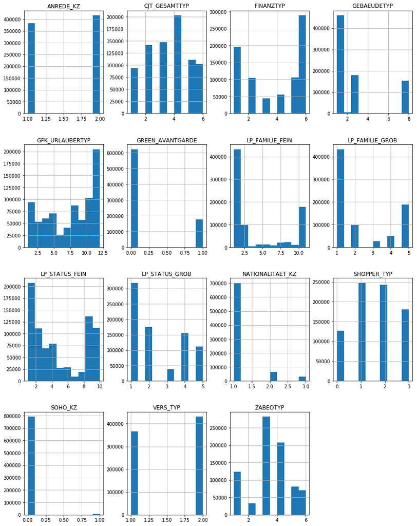

```python
# Below I'm plotting the categorical features

fig = plt.figure(figsize = (15,20))
ax = fig.gca()
azdias_new4 [feat_info_cat ['attribute'] ].hist(ax = ax)
```

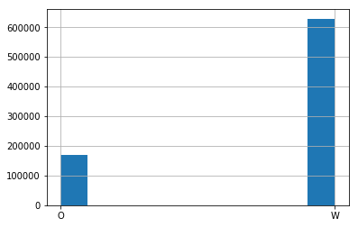

```python
# OST_WEST_KZ contains non-numeric values
azdias_new4['OST_WEST_KZ'].hist()
```

```python
# Re-encode categorical variable(s) to be kept in the analysis.
azdias_new4.OST_WEST_KZ = azdias_new4.OST_WEST_KZ.replace ({'O': 0.0,
                                                            'W': 1.0})
```

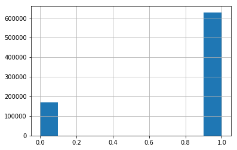

```python
# Now OST_WEST_KZ now contains numeric values
azdias_new4 ['OST_WEST_KZ'].hist()
```

```python
# preparing a list for get_dummies (one hot encoding)
list_enc = []

for column in (feat_info_cat ['attribute']):
    print (column) #printing feature name
    unv_values = azdias_new4 [column].unique ()
    display (unv_values)
    if unv_values.size > 2: #we only need features containing more than 2 possible values
        list_enc.append (column)

# for these features we need to apply one hot encoding
list_enc
```

```
ANREDE_KZ
```

```
array([ 2.,  1.])
```

```
CJT_GESAMTTYP
```

```
array([ 5.,  3.,  2.,  4.,  1.,  6.])
```

```
FINANZTYP
```

```
array([ 1.,  6.,  5.,  2.,  4.,  3.])
```

```
GFK_URLAUBERTYP
```

```
array([ 10.,   1.,   5.,  12.,   9.,   3.,   8.,  11.,   4.,   2.,   7.,
         6.])
```

```
GREEN_AVANTGARDE
```

```
array([0, 1])
```

```
LP_FAMILIE_FEIN
```

```
array([  5.,   1.,  10.,   2.,   7.,  11.,   8.,   4.,   6.,   9.,   3.])
```

```
LP_FAMILIE_GROB
```

```
array([ 3.,  1.,  5.,  2.,  4.])
```

```
LP_STATUS_FEIN
```

```
array([  2.,   3.,   9.,   4.,   1.,  10.,   5.,   8.,   6.,   7.])
```

```
LP_STATUS_GROB
```

```
array([ 1.,  2.,  4.,  5.,  3.])
```

```
NATIONALITAET_KZ
```

```
array([ 1.,  3.,  2.])
```

```
SHOPPER_TYP
```

```
array([ 3.,  2.,  1.,  0.])
```

```
SOHO_KZ
```

```
array([ 1.,  0.])
```

```
VERS_TYP
```

```
array([ 2.,  1.])
```

```
ZABEOTYP
```

```
array([ 5.,  3.,  4.,  1.,  6.,  2.])
```

```
GEBAEUDETYP
```

```
array([ 8.,  1.,  3.,  2.,  6.,  4.,  5.])
```

```
OST_WEST_KZ
```

```
array([ 1.,  0.])
```

```
CAMEO_DEUG_2015
```

```
array(['8', '4', '2', '6', '1', '9', '5', '7', '3'], dtype=object)
```

```
CAMEO_DEU_2015
```

```
array(['8A', '4C', '2A', '6B', '8C', '4A', '2D', '1A', '1E', '9D', '5C',
       '8B', '7A', '5D', '9E', '9B', '1B', '3D', '4E', '4B', '3C', '5A',
       '7B', '9A', '6D', '6E', '2C', '7C', '9C', '7D', '5E', '1D', '8D',
       '6C', '6A', '5B', '4D', '3A', '2B', '7E', '3B', '6F', '5F', '1C'], dtype=object)
```

```
['CJT_GESAMTTYP',
 'FINANZTYP',
 'GFK_URLAUBERTYP',
 'LP_FAMILIE_FEIN',
 'LP_FAMILIE_GROB',
 'LP_STATUS_FEIN',
 'LP_STATUS_GROB',
 'NATIONALITAET_KZ',
 'SHOPPER_TYP',
 'ZABEOTYP',
 'GEBAEUDETYP',
 'CAMEO_DEUG_2015',
 'CAMEO_DEU_2015']
```

```python
# performing one hot encoding
azdias_new5 = pd.get_dummies (azdias_new4, columns = list_enc)
print (azdias_new5.shape)
display (list (azdias_new5.columns))
```

```
(797077, 195)
```

```
['ALTERSKATEGORIE_GROB',
 'ANREDE_KZ',
 'FINANZ_MINIMALIST',
 'FINANZ_SPARER',
 'FINANZ_VORSORGER',
 'FINANZ_ANLEGER',
 'FINANZ_UNAUFFAELLIGER',
 'FINANZ_HAUSBAUER',
 'GREEN_AVANTGARDE',
 'HEALTH_TYP',
 'LP_LEBENSPHASE_FEIN',
 'LP_LEBENSPHASE_GROB',
 'PRAEGENDE_JUGENDJAHRE',
 'RETOURTYP_BK_S',
 'SEMIO_SOZ',
 'SEMIO_FAM',
 'SEMIO_REL',
 'SEMIO_MAT',
 'SEMIO_VERT',
 'SEMIO_LUST',
 'SEMIO_ERL',
 'SEMIO_KULT',
 'SEMIO_RAT',
 'SEMIO_KRIT',
 'SEMIO_DOM',
 'SEMIO_KAEM',
 'SEMIO_PFLICHT',
 'SEMIO_TRADV',
 'SOHO_KZ',
 'VERS_TYP',
 'ANZ_PERSONEN',
 'ANZ_TITEL',
 'HH_EINKOMMEN_SCORE',
 'W_KEIT_KIND_HH',
 'WOHNDAUER_2008',
 'ANZ_HAUSHALTE_AKTIV',
 'ANZ_HH_TITEL',
 'KONSUMNAEHE',
 'MIN_GEBAEUDEJAHR',
 'OST_WEST_KZ',
```

[output cut: 140 more lines]

```
 'CAMEO_DEU_2015_6F',
 'CAMEO_DEU_2015_7A',
 'CAMEO_DEU_2015_7B',
 'CAMEO_DEU_2015_7C',
 'CAMEO_DEU_2015_7D',
 'CAMEO_DEU_2015_7E',
 'CAMEO_DEU_2015_8A',
 'CAMEO_DEU_2015_8B',
 'CAMEO_DEU_2015_8C',
 'CAMEO_DEU_2015_8D',
 'CAMEO_DEU_2015_9A',
 'CAMEO_DEU_2015_9B',
 'CAMEO_DEU_2015_9C',
 'CAMEO_DEU_2015_9D',
 'CAMEO_DEU_2015_9E']
```

```python
azdias_new5 = azdias_new5.drop(columns=['missing_in_rows'])
azdias_new5.shape
```

```
(797077, 194)
```

#### Discussion 1.2.1: Re-Encode Categorical Features

No changes were done for binary categories which has numeric values. For binary variable OST_WEST_KZ, which was a non-numeric binary feature, I have replaced 'O' as 0 and 'W' as '1'. OneHotEncoding was used for multi-level categoricals (with three or more values).

I thought not to drop any features, so that I won't miss any potential prominent variable.

#### Step 1.2.2: Engineer Mixed-Type Features

There are a handful of features that are marked as "mixed" in the feature summary that require special treatment in order to be included in the analysis. There are two in particular that deserve attention; the handling of the rest are up to your own choices:

- "PRAEGENDE_JUGENDJAHRE" combines information on three dimensions: generation by decade, movement (mainstream vs. avantgarde), and nation (east vs. west). While there aren't enough levels to disentangle east from west, you should create two new variables to capture the other two dimensions: an interval-type variable for decade, and a binary variable for movement.
- "CAMEO_INTL_2015" combines information on two axes: wealth and life stage. Break up the two-digit codes by their 'tens'-place and 'ones'-place digits into two new ordinal variables (which, for the purposes of this project, is equivalent to just treating them as their raw numeric values).
- If you decide to keep or engineer new features around the other mixed-type features, make sure you note your steps in the Discussion section.

Be sure to check `Data_Dictionary.md` for the details needed to finish these tasks.

```python
# Identify all mixed type variables

feat_info_mix = feat_info_new [ feat_info_new ['type'] =='mixed']
display (feat_info_mix)
```

|  | attribute | information_level | type | missing_or_unknown |
| --- | --- | --- | --- | --- |
| 15 | LP_LEBENSPHASE_FEIN | person | mixed | [0] |
| 16 | LP_LEBENSPHASE_GROB | person | mixed | [0] |
| 22 | PRAEGENDE_JUGENDJAHRE | person | mixed | [-1,0] |
| 56 | WOHNLAGE | building | mixed | [-1] |
| 59 | CAMEO_INTL_2015 | microcell_rr4 | mixed | [-1,XX] |
| 79 | PLZ8_BAUMAX | macrocell_plz8 | mixed | [-1,0] |

```python
# Identifying unique values of mixed type features.

for column in (feat_info_mix ['attribute']):
    print (column) #printing feature name
    unq_values = azdias_new5 [column].unique () #returns list of unique values
    display (unq_values)
```

```
LP_LEBENSPHASE_FEIN
```

```
array([ 21.,   3.,  13.,  32.,   8.,   2.,   5.,  10.,   4.,   6.,  23.,
        12.,  20.,   1.,  11.,  25.,  18.,  31.,  38.,  35.,  30.,   7.,
        22.,  14.,  29.,  24.,  28.,  37.,  26.,  39.,  27.,  36.,   9.,
        34.,  33.,  15.,  40.,  16.,  19.,  17.])
```

```
LP_LEBENSPHASE_GROB
```

```
array([  6.,   1.,   3.,  10.,   2.,   5.,   7.,  12.,  11.,   9.,   4.,
         8.])
```

```
PRAEGENDE_JUGENDJAHRE
```

```
array([ 14.,  15.,   8.,   3.,  10.,  11.,   5.,   9.,   6.,   4.,   2.,
         1.,  12.,  13.,   7.])
```

```
WOHNLAGE
```

```
array([ 4.,  2.,  7.,  3.,  5.,  1.,  8.,  0.])
```

```
CAMEO_INTL_2015
```

```
array(['51', '24', '12', '43', '54', '22', '14', '13', '15', '33', '41',
       '34', '55', '25', '23', '31', '52', '35', '45', '44', '32'], dtype=object)
```

```
PLZ8_BAUMAX
```

```
array([ 1.,  2.,  4.,  5.,  3.])
```

```python
# Investigate "PRAEGENDE_JUGENDJAHRE" and engineer two new variables.

#it appears that "PRAEGENDE_JUGENDJAHRE" should be devided into 2 variables:
#first will stand for decade, e.g. 40s, 50s, etc.
#second will be for Avantgarde vs. Mainstream

#Thus, column "PRAEGENDE_JUGENDJAHRE" is copied into new columns: PRAEGENDE_JUGENDJAHRE_AM (Avantgarde vs. Mainstream)
#and PRAEGENDE_JUGENDJAHRE_DC (Decades)

#Original PRAEGENDE_JUGENDJAHRE values will be dropped later on.

azdias_new5 ['PRAEGENDE_JUGENDJAHRE_AM'] = azdias_new5 ['PRAEGENDE_JUGENDJAHRE']

azdias_new5 ['PRAEGENDE_JUGENDJAHRE_DC'] = azdias_new5 ['PRAEGENDE_JUGENDJAHRE']

# Let's encode PRAEGENDE_JUGENDJAHRE and PRAEGENDE_JUGENDJAHRE_AM

dict1 ={1: 40.0,
        2: 40.0,
        3: 50.0,
        4: 50.0,
        5: 60.0,
        6: 60.0,
        7: 60.0,
        8: 70.0,
        9: 70.0,
        10: 80.0,
        11: 80.0,
        12: 80.0,
        13: 80.0,
        14: 90.0,
        15: 90.0,
        }

#replacing with decade values
azdias_new5.PRAEGENDE_JUGENDJAHRE_DC = azdias_new5.PRAEGENDE_JUGENDJAHRE_DC.replace (dict1)

#replacing where Mainstream encoded as 0 and avantgarde as 1
dict2 ={1: 0.0,
        2: 1.0,
        3: 0.0,
        4: 1.0,
        5: 0.0,
        6: 1.0,
        7: 1.0,
        8: 0.0,
        9: 1.0,
        10: 0.0,
        11: 1.0,
        12: 0.0,
        13: 1.0,
        14: 0.0,
        15: 1.0,
        }

azdias_new5.PRAEGENDE_JUGENDJAHRE_AM = azdias_new5.PRAEGENDE_JUGENDJAHRE_AM.replace (dict2)
```

```python
display (azdias_new5.head (n=10))
```

|  | ALTERSKATEGORIE_GROB | ANREDE_KZ | FINANZ_MINIMALIST | FINANZ_SPARER | FINANZ_VORSORGER | FINANZ_ANLEGER | FINANZ_UNAUFFAELLIGER | FINANZ_HAUSBAUER | GREEN_AVANTGARDE | HEALTH_TYP | ... | CAMEO_DEU_2015_8B | CAMEO_DEU_2015_8C | CAMEO_DEU_2015_8D | CAMEO_DEU_2015_9A | CAMEO_DEU_2015_9B | CAMEO_DEU_2015_9C | CAMEO_DEU_2015_9D | CAMEO_DEU_2015_9E | PRAEGENDE_JUGENDJAHRE_AM | PRAEGENDE_JUGENDJAHRE_DC |
| --- | --- | --- | --- | --- | --- | --- | --- | --- | --- | --- | --- | --- | --- | --- | --- | --- | --- | --- | --- | --- | --- |
| 1 | 1.0 | 2.0 | 1.0 | 5.0 | 2.0 | 5.0 | 4.0 | 5.0 | 0 | 3.0 | ... | 0 | 0 | 0 | 0 | 0 | 0 | 0 | 0 | 0.0 | 90.0 |
| 2 | 3.0 | 2.0 | 1.0 | 4.0 | 1.0 | 2.0 | 3.0 | 5.0 | 1 | 3.0 | ... | 0 | 0 | 0 | 0 | 0 | 0 | 0 | 0 | 1.0 | 90.0 |
| 3 | 4.0 | 2.0 | 4.0 | 2.0 | 5.0 | 2.0 | 1.0 | 2.0 | 0 | 2.0 | ... | 0 | 0 | 0 | 0 | 0 | 0 | 0 | 0 | 0.0 | 70.0 |
| 4 | 3.0 | 1.0 | 4.0 | 3.0 | 4.0 | 1.0 | 3.0 | 2.0 | 0 | 3.0 | ... | 0 | 0 | 0 | 0 | 0 | 0 | 0 | 0 | 0.0 | 70.0 |
| 5 | 1.0 | 2.0 | 3.0 | 1.0 | 5.0 | 2.0 | 2.0 | 5.0 | 0 | 3.0 | ... | 0 | 1 | 0 | 0 | 0 | 0 | 0 | 0 | 0.0 | 50.0 |
| 6 | 2.0 | 2.0 | 1.0 | 5.0 | 1.0 | 5.0 | 4.0 | 3.0 | 0 | 2.0 | ... | 0 | 0 | 0 | 0 | 0 | 0 | 0 | 0 | 0.0 | 80.0 |
| 7 | 1.0 | 1.0 | 3.0 | 3.0 | 4.0 | 1.0 | 3.0 | 2.0 | 0 | 1.0 | ... | 0 | 0 | 0 | 0 | 0 | 0 | 0 | 0 | 0.0 | 70.0 |
| 8 | 3.0 | 1.0 | 4.0 | 4.0 | 2.0 | 4.0 | 2.0 | 2.0 | 1 | 3.0 | ... | 0 | 0 | 0 | 0 | 0 | 0 | 0 | 0 | 1.0 | 80.0 |
| 9 | 3.0 | 2.0 | 2.0 | 4.0 | 2.0 | 3.0 | 5.0 | 4.0 | 1 | 2.0 | ... | 0 | 0 | 0 | 0 | 0 | 0 | 0 | 0 | 1.0 | 90.0 |
| 10 | 3.0 | 2.0 | 2.0 | 2.0 | 5.0 | 3.0 | 1.0 | 5.0 | 0 | 2.0 | ... | 0 | 0 | 0 | 0 | 0 | 0 | 1 | 0 | 0.0 | 50.0 |

10 rows × 196 columns

```python
# Investigate "CAMEO_INTL_2015" and engineer two new variables.

#"CAMEO_INTL_2015" should be devided into 2 variables: wealth and life stage

#Wealth can be coded as (in the new column CAMEO_INTL_2015_WL):
#Wealthy Households: 1
#Prosperous Households: 2
#Comfortable Households: 3
#Less Affluent Households: 4
#Poorer Households: 5

#Life stage as (in new column CAMEO_INTL_2015_LS):
#Pre-Family: 0
#Young Couples: 1
#Families: 2
#Older Families: 3
#Elders: 4

#Let's copy column "CAMEO_INTL_2015" to a new column: CAMEO_INTL_2015_LS
azdias_new5 ['CAMEO_INTL_2015_LS'] = azdias_new5 ['CAMEO_INTL_2015']
azdias_new5 ['CAMEO_INTL_2015_WL'] = azdias_new5 ['CAMEO_INTL_2015']

# Encoding CAMEO_INTL_2015 and CAMEO_INTL_2015_LS

# ************** numbers were as str and not int so could not convert from 1st attempt.

#replacing with wealth codes
dict3 = {'11': 1.0,
            '12': 1.0,
            '13': 1.0,
            '14': 1.0,
            '15': 1.0,
            '21': 2.0,
            '22': 2.0,
            '23': 2.0,
            '24': 2.0,
            '25': 2.0,
            '31': 3.0,
            '32': 3.0,
            '33': 3.0,
            '34': 3.0,
            '35': 3.0,
            '41': 4.0,
            '42': 4.0,
            '43': 4.0,
            '44': 4.0,
            '45': 4.0,
            '51': 5.0,
            '52': 5.0,
            '53': 5.0,
            '54': 5.0,
            '55': 5.0,
        }

azdias_new5.CAMEO_INTL_2015_WL = azdias_new5.CAMEO_INTL_2015_WL.replace (dict3)

#replacing values for family life stage
dict4 = {'11': 1.0,
            '12': 2.0,
            '13': 3.0,
            '14': 4.0,
            '15': 5.0,
            '21': 1.0,
            '22': 2.0,
            '23': 3.0,
            '24': 4.0,
            '25': 5.0,
            '31': 1.0,
            '32': 2.0,
            '33': 3.0,
            '34': 4.0,
            '35': 5.0,
            '41': 1.0,
            '42': 2.0,
            '43': 3.0,
            '44': 4.0,
            '45': 5.0,
            '51': 1.0,
            '52': 2.0,
            '53': 3.0,
            '54': 4.0,
            '55': 5.0,
        }

azdias_new5.CAMEO_INTL_2015_LS = azdias_new5.CAMEO_INTL_2015_LS.replace (dict4)
```

```python
display (azdias_new5.head (n=10))
```

|  | ALTERSKATEGORIE_GROB | ANREDE_KZ | FINANZ_MINIMALIST | FINANZ_SPARER | FINANZ_VORSORGER | FINANZ_ANLEGER | FINANZ_UNAUFFAELLIGER | FINANZ_HAUSBAUER | GREEN_AVANTGARDE | HEALTH_TYP | ... | CAMEO_DEU_2015_8D | CAMEO_DEU_2015_9A | CAMEO_DEU_2015_9B | CAMEO_DEU_2015_9C | CAMEO_DEU_2015_9D | CAMEO_DEU_2015_9E | PRAEGENDE_JUGENDJAHRE_AM | PRAEGENDE_JUGENDJAHRE_DC | CAMEO_INTL_2015_LS | CAMEO_INTL_2015_WL |
| --- | --- | --- | --- | --- | --- | --- | --- | --- | --- | --- | --- | --- | --- | --- | --- | --- | --- | --- | --- | --- | --- |
| 1 | 1.0 | 2.0 | 1.0 | 5.0 | 2.0 | 5.0 | 4.0 | 5.0 | 0 | 3.0 | ... | 0 | 0 | 0 | 0 | 0 | 0 | 0.0 | 90.0 | 1.0 | 5.0 |
| 2 | 3.0 | 2.0 | 1.0 | 4.0 | 1.0 | 2.0 | 3.0 | 5.0 | 1 | 3.0 | ... | 0 | 0 | 0 | 0 | 0 | 0 | 1.0 | 90.0 | 4.0 | 2.0 |
| 3 | 4.0 | 2.0 | 4.0 | 2.0 | 5.0 | 2.0 | 1.0 | 2.0 | 0 | 2.0 | ... | 0 | 0 | 0 | 0 | 0 | 0 | 0.0 | 70.0 | 2.0 | 1.0 |
| 4 | 3.0 | 1.0 | 4.0 | 3.0 | 4.0 | 1.0 | 3.0 | 2.0 | 0 | 3.0 | ... | 0 | 0 | 0 | 0 | 0 | 0 | 0.0 | 70.0 | 3.0 | 4.0 |
| 5 | 1.0 | 2.0 | 3.0 | 1.0 | 5.0 | 2.0 | 2.0 | 5.0 | 0 | 3.0 | ... | 0 | 0 | 0 | 0 | 0 | 0 | 0.0 | 50.0 | 4.0 | 5.0 |
| 6 | 2.0 | 2.0 | 1.0 | 5.0 | 1.0 | 5.0 | 4.0 | 3.0 | 0 | 2.0 | ... | 0 | 0 | 0 | 0 | 0 | 0 | 0.0 | 80.0 | 2.0 | 2.0 |
| 7 | 1.0 | 1.0 | 3.0 | 3.0 | 4.0 | 1.0 | 3.0 | 2.0 | 0 | 1.0 | ... | 0 | 0 | 0 | 0 | 0 | 0 | 0.0 | 70.0 | 4.0 | 1.0 |
| 8 | 3.0 | 1.0 | 4.0 | 4.0 | 2.0 | 4.0 | 2.0 | 2.0 | 1 | 3.0 | ... | 0 | 0 | 0 | 0 | 0 | 0 | 1.0 | 80.0 | 3.0 | 1.0 |
| 9 | 3.0 | 2.0 | 2.0 | 4.0 | 2.0 | 3.0 | 5.0 | 4.0 | 1 | 2.0 | ... | 0 | 0 | 0 | 0 | 0 | 0 | 1.0 | 90.0 | 5.0 | 1.0 |
| 10 | 3.0 | 2.0 | 2.0 | 2.0 | 5.0 | 3.0 | 1.0 | 5.0 | 0 | 2.0 | ... | 0 | 0 | 0 | 0 | 1 | 0 | 0.0 | 50.0 | 1.0 | 5.0 |

10 rows × 198 columns

#### Discussion 1.2.2: Engineer Mixed-Type Features

RAEGENDE_JUGENDJAHRE - re-encoded above.

It appeared that "PRAEGENDE_JUGENDJAHRE" should be divided into 2 variables: first will stand for decade, e.g. 40s, 50s, etc. second will be for Avantgarde vs. Mainstream I have copied column "PRAEGENDE_JUGENDJAHRE" to new columns: PRAEGENDE_JUGENDJAHRE_AM (Avantgarde vs. Mainstream) and PRAEGENDE_JUGENDJAHRE_DC (Decades) Original PRAEGENDE_JUGENDJAHRE values will be dropped.

CAMEO_INTL_2015 - re-encoded above. It appeared that "CAMEO_INTL_2015" should be divided into 2 variables: wealth and life stage

Wealth can be coded as (in the new column CAMEO_INTL_2015_WL): Wealthy Households: 1 Prosperous Households: 2 Comfortable Households: 3 Less Affluent Households: 4 Poorer Households: 5

LP_LEBENSPHASE_FEIN (life stage, fine scale) - contains multiple slices of person and social status like: single/couple/family, income, age, homeowners, single parent. From presented possible values it is impossible to generate for each and every slice a feature that would certainly contain a value, not NaN. However it is useful to keep this feature as it might overlap with customer data.

LP_LEBENSPHASE_GROB (life stage, rough scale)- pretty similar to LP_LEBENSPHASE_FEIN, where it is rough scale. All the arguments the same here: contains multiple slices of person and social status like single/couple/family, income, age, homeowners, single parent. From presented possible values it is impossible to generate for each and every slice a feature that would certainly contain a value, not NaN. However it is useful to keep this feature as it might overlap with customer data.

WOHNLAGE (neighborhood) - I decided to drop this feature as possible values are mixed, not categorical and as per PCA analysis this feature plays very minor role (previously I kept it).

PLZ8_BAUMAX (building) - I decided to drop this feature as it is not categorical and almost fully covered from PLZ8_ANTG1 to PLZ8_ANTG4 except for commercial buildings which should not play major role in the analysis.

#### Step 1.2.3: Complete Feature Selection

In order to finish this step up, you need to make sure that your data frame now only has the columns that you want to keep. To summarize, the dataframe should consist of the following:

- All numeric, interval, and ordinal type columns from the original dataset.
- Binary categorical features (all numerically-encoded).
- Engineered features from other multi-level categorical features and mixed features.

Make sure that for any new columns that you have engineered, that you've excluded the original columns from the final dataset. Otherwise, their values will interfere with the analysis later on the project. For example, you should not keep "PRAEGENDE_JUGENDJAHRE", since its values won't be useful for the algorithm: only the values derived from it in the engineered features you created should be retained. As a reminder, your data should only be from **the subset with few or no missing values**.

```python
# Do whatever you need to in order to ensure that the dataframe only contains
# the columns that should be passed to the algorithm functions.

print(azdias_new5.shape)

#dropping columns that were substituted by new features and the features decided to be dropped.
azdias_new5.drop (['PRAEGENDE_JUGENDJAHRE', 'CAMEO_INTL_2015', 'WOHNLAGE', 'PLZ8_BAUMAX'], axis = 1, inplace = True)

display (azdias_new5.head (n=10))
```

```
(797077, 198)
```

|  | ALTERSKATEGORIE_GROB | ANREDE_KZ | FINANZ_MINIMALIST | FINANZ_SPARER | FINANZ_VORSORGER | FINANZ_ANLEGER | FINANZ_UNAUFFAELLIGER | FINANZ_HAUSBAUER | GREEN_AVANTGARDE | HEALTH_TYP | ... | CAMEO_DEU_2015_8D | CAMEO_DEU_2015_9A | CAMEO_DEU_2015_9B | CAMEO_DEU_2015_9C | CAMEO_DEU_2015_9D | CAMEO_DEU_2015_9E | PRAEGENDE_JUGENDJAHRE_AM | PRAEGENDE_JUGENDJAHRE_DC | CAMEO_INTL_2015_LS | CAMEO_INTL_2015_WL |
| --- | --- | --- | --- | --- | --- | --- | --- | --- | --- | --- | --- | --- | --- | --- | --- | --- | --- | --- | --- | --- | --- |
| 1 | 1.0 | 2.0 | 1.0 | 5.0 | 2.0 | 5.0 | 4.0 | 5.0 | 0 | 3.0 | ... | 0 | 0 | 0 | 0 | 0 | 0 | 0.0 | 90.0 | 1.0 | 5.0 |
| 2 | 3.0 | 2.0 | 1.0 | 4.0 | 1.0 | 2.0 | 3.0 | 5.0 | 1 | 3.0 | ... | 0 | 0 | 0 | 0 | 0 | 0 | 1.0 | 90.0 | 4.0 | 2.0 |
| 3 | 4.0 | 2.0 | 4.0 | 2.0 | 5.0 | 2.0 | 1.0 | 2.0 | 0 | 2.0 | ... | 0 | 0 | 0 | 0 | 0 | 0 | 0.0 | 70.0 | 2.0 | 1.0 |
| 4 | 3.0 | 1.0 | 4.0 | 3.0 | 4.0 | 1.0 | 3.0 | 2.0 | 0 | 3.0 | ... | 0 | 0 | 0 | 0 | 0 | 0 | 0.0 | 70.0 | 3.0 | 4.0 |
| 5 | 1.0 | 2.0 | 3.0 | 1.0 | 5.0 | 2.0 | 2.0 | 5.0 | 0 | 3.0 | ... | 0 | 0 | 0 | 0 | 0 | 0 | 0.0 | 50.0 | 4.0 | 5.0 |
| 6 | 2.0 | 2.0 | 1.0 | 5.0 | 1.0 | 5.0 | 4.0 | 3.0 | 0 | 2.0 | ... | 0 | 0 | 0 | 0 | 0 | 0 | 0.0 | 80.0 | 2.0 | 2.0 |
| 7 | 1.0 | 1.0 | 3.0 | 3.0 | 4.0 | 1.0 | 3.0 | 2.0 | 0 | 1.0 | ... | 0 | 0 | 0 | 0 | 0 | 0 | 0.0 | 70.0 | 4.0 | 1.0 |
| 8 | 3.0 | 1.0 | 4.0 | 4.0 | 2.0 | 4.0 | 2.0 | 2.0 | 1 | 3.0 | ... | 0 | 0 | 0 | 0 | 0 | 0 | 1.0 | 80.0 | 3.0 | 1.0 |
| 9 | 3.0 | 2.0 | 2.0 | 4.0 | 2.0 | 3.0 | 5.0 | 4.0 | 1 | 2.0 | ... | 0 | 0 | 0 | 0 | 0 | 0 | 1.0 | 90.0 | 5.0 | 1.0 |
| 10 | 3.0 | 2.0 | 2.0 | 2.0 | 5.0 | 3.0 | 1.0 | 5.0 | 0 | 2.0 | ... | 0 | 0 | 0 | 0 | 1 | 0 | 0.0 | 50.0 | 1.0 | 5.0 |

10 rows × 194 columns

### Step 1.3: Create a Cleaning Function

Even though you've finished cleaning up the general population demographics data, it's important to look ahead to the future and realize that you'll need to perform the same cleaning steps on the customer demographics data. In this substep, complete the function below to execute the main feature selection, encoding, and re-engineering steps you performed above. Then, when it comes to looking at the customer data in Step 3, you can just run this function on that DataFrame to get the trimmed dataset in a single step.

```python
def clean_data(df):
    """
    Perform feature trimming, re-encoding, and engineering for demographics
    data

    INPUT: Demographics DataFrame
    OUTPUT: Trimmed and cleaned demographics DataFrame
    """

    # Put in code here to execute all main cleaning steps:
    # convert missing value codes into NaNs, ...

    #filling missing or unknown values with NaN as per the created list miss_val
    cl_df = df

    for item in range (len (miss_val)):
        column_name = feat_info.iloc [item] ['attribute'] #saving column name
        cl_df[column_name].replace (to_replace = miss_val [item], value = np.NaN, regex = True, inplace = True)

    # remove selected columns and rows, ...
    # drop columns with more than 20% missing values
    columns_miss_20 = ['AGER_TYP', 'GEBURTSJAHR', 'TITEL_KZ', 'ALTER_HH', 'KK_KUNDENTYP', 'KBA05_BAUMAX']
    cl_df1 = cl_df.drop(columns_miss_20, axis=1)

    #adding a column reflecting missing values in each row respectively
    rows_mis = pd.DataFrame (cl_df1.isnull().sum (axis = 1), columns = ['missing_in_rows'])
    cl_df2 = cl_df1.join (rows_mis)

    #dropping rows that contains less than 20 missing values in a row and saving rows which contains 20 or more missing values.
    cl_df3 = cl_df2 [ cl_df2 ['missing_in_rows'] <=20]

    #storing dataframe of rows that contains 20 or more than 20 missing values in a row.
    cl_df_more_than_20 = cl_df2 [ cl_df2 ['missing_in_rows'] >20]
    cl_df_more_than_20.columns = cl_df2.columns
    cl_df_more_than_20 = cl_df_more_than_20.drop ('missing_in_rows', axis = 1) #we don't need this column anymore.


    #storing number of dropped rows and returning from function
    drop_rows = cl_df2 [ cl_df2 ['missing_in_rows'] >20].shape [0]

    #storing number of rows (including with missing values)
    rows_number = cl_df2.shape [0]

    #storing indeces
    index = cl_df3.index

    cl_df3 = cl_df3.drop ('missing_in_rows', axis = 1) #we don't need this column anymore.

    #Applying imputation for residual missing values (not more than 10 in a row) using sklearn. Will run it over columns
    #as all values of a feature presented within a single column.

    cl_df3_im = pd.DataFrame (DFImputer ().fit_transform (cl_df3)) #preparing new datafram with imputed values.
    cl_df3_im.columns = cl_df3.columns #restoring column names
    cl_df3_im.index = cl_df3.index #restoring indeces
    cl_df3 = cl_df3_im #saving result

    print ('Shape before binary encoding',cl_df3.shape)
    #encoding features
    cl_df3.OST_WEST_KZ = cl_df3.OST_WEST_KZ.replace ({'O': 0.0,
                                                      'W': 1.0})

    print ('Shape before one hot encoding',cl_df3.shape)

    cl_df4 = pd.get_dummies (cl_df3, columns = list_enc)

    print ('Shape after one hot encoding',cl_df4.shape)

    cl_df4 ['PRAEGENDE_JUGENDJAHRE_AM'] = cl_df4 ['PRAEGENDE_JUGENDJAHRE']
    cl_df4 ['PRAEGENDE_JUGENDJAHRE_DC'] = cl_df4 ['PRAEGENDE_JUGENDJAHRE']

    cl_df4.PRAEGENDE_JUGENDJAHRE_DC = cl_df4.PRAEGENDE_JUGENDJAHRE_DC.replace (dict1)
    cl_df4.PRAEGENDE_JUGENDJAHRE_AM = cl_df4.PRAEGENDE_JUGENDJAHRE_AM.replace (dict2)

    cl_df4 ['CAMEO_INTL_2015_LS'] = cl_df4 ['CAMEO_INTL_2015']
    cl_df4 ['CAMEO_INTL_2015_WL'] = cl_df4 ['CAMEO_INTL_2015']

    cl_df4.CAMEO_INTL_2015_WL = cl_df4.CAMEO_INTL_2015_WL.replace (dict3)
    cl_df4.CAMEO_INTL_2015_LS = cl_df4.CAMEO_INTL_2015_LS.replace (dict4)

    print ('Shape after mix value change',cl_df4.shape)

    cl_df4.drop (['PRAEGENDE_JUGENDJAHRE', 'CAMEO_INTL_2015', 'WOHNLAGE', 'PLZ8_BAUMAX'], axis = 1, inplace = True)

    print ('Shape after dropping additional columns',cl_df4.shape)

    # Return the cleaned dataframe and other data.
    return cl_df4, drop_rows, rows_number, index, cl_df_more_than_20
```

## Step 2: Feature Transformation

### Step 2.1: Apply Feature Scaling

Before we apply dimensionality reduction techniques to the data, we need to perform feature scaling so that the principal component vectors are not influenced by the natural differences in scale for features. Starting from this part of the project, you'll want to keep an eye on the [API reference page for sklearn](http://scikit-learn.org/stable/modules/classes.html) to help you navigate to all of the classes and functions that you'll need. In this substep, you'll need to check the following:

- sklearn requires that data not have missing values in order for its estimators to work properly. So, before applying the scaler to your data, make sure that you've cleaned the DataFrame of the remaining missing values. This can be as simple as just removing all data points with missing data, or applying an [Imputer](http://scikit-learn.org/stable/modules/generated/sklearn.preprocessing.Imputer.html) to replace all missing values. You might also try a more complicated procedure where you temporarily remove missing values in order to compute the scaling parameters before re-introducing those missing values and applying imputation. Think about how much missing data you have and what possible effects each approach might have on your analysis, and justify your decision in the discussion section below.
- For the actual scaling function, a [StandardScaler](http://scikit-learn.org/stable/modules/generated/sklearn.preprocessing.StandardScaler.html) instance is suggested, scaling each feature to mean 0 and standard deviation 1.
- For these classes, you can make use of the `.fit_transform()` method to both fit a procedure to the data as well as apply the transformation to the data at the same time. Don't forget to keep the fit sklearn objects handy, since you'll be applying them to the customer demographics data towards the end of the project.

```python
# Apply feature scaling to the general population demographics data.

scaler = StandardScaler()
azdias6 = pd.DataFrame (scaler.fit_transform (azdias_new5))

azdias6.columns = azdias_new5.columns #restoring column names
azdias6.index = azdias_new5.index #restoring indeces

display (azdias6.head (n=10)) #verifying result
```

|  | ALTERSKATEGORIE_GROB | ANREDE_KZ | FINANZ_MINIMALIST | FINANZ_SPARER | FINANZ_VORSORGER | FINANZ_ANLEGER | FINANZ_UNAUFFAELLIGER | FINANZ_HAUSBAUER | GREEN_AVANTGARDE | HEALTH_TYP | ... | CAMEO_DEU_2015_8D | CAMEO_DEU_2015_9A | CAMEO_DEU_2015_9B | CAMEO_DEU_2015_9C | CAMEO_DEU_2015_9D | CAMEO_DEU_2015_9E | PRAEGENDE_JUGENDJAHRE_AM | PRAEGENDE_JUGENDJAHRE_DC | CAMEO_INTL_2015_LS | CAMEO_INTL_2015_WL |
| --- | --- | --- | --- | --- | --- | --- | --- | --- | --- | --- | --- | --- | --- | --- | --- | --- | --- | --- | --- | --- | --- |
| 1 | -1.766173 | 0.958121 | -1.494463 | 1.538139 | -1.040664 | 1.466401 | 0.959974 | 1.338532 | -0.530654 | 1.095917 | ... | -0.150111 | -0.162625 | -0.189607 | -0.179893 | -0.192884 | -0.089706 | -0.585443 | 1.172665 | -1.249369 | 1.175857 |
| 2 | 0.200733 | 0.958121 | -1.494463 | 0.864753 | -1.766903 | -0.570914 | 0.245238 | 1.338532 | 1.884467 | 1.095917 | ... | -0.150111 | -0.162625 | -0.189607 | -0.179893 | -0.192884 | -0.089706 | 1.708107 | 1.172665 | 0.766691 | -0.869590 |
| 3 | 1.184186 | 0.958121 | 0.683285 | -0.482020 | 1.138052 | -0.570914 | -1.184235 | -0.792444 | -0.530654 | -0.257476 | ... | -0.150111 | -0.162625 | -0.189607 | -0.179893 | -0.192884 | -0.089706 | -0.585443 | -0.223457 | -0.577349 | -1.551406 |
| 4 | 0.200733 | -1.043709 | 0.683285 | 0.191366 | 0.411813 | -1.250019 | 0.245238 | -0.792444 | -0.530654 | 1.095917 | ... | -0.150111 | -0.162625 | -0.189607 | -0.179893 | -0.192884 | -0.089706 | -0.585443 | -0.223457 | 0.094671 | 0.494041 |
| 5 | -1.766173 | 0.958121 | -0.042631 | -1.155407 | 1.138052 | -0.570914 | -0.469499 | 1.338532 | -0.530654 | 1.095917 | ... | -0.150111 | -0.162625 | -0.189607 | -0.179893 | -0.192884 | -0.089706 | -0.585443 | -1.619579 | 0.766691 | 1.175857 |
| 6 | -0.782720 | 0.958121 | -1.494463 | 1.538139 | -1.766903 | 1.466401 | 0.959974 | -0.082119 | -0.530654 | -0.257476 | ... | -0.150111 | -0.162625 | -0.189607 | -0.179893 | -0.192884 | -0.089706 | -0.585443 | 0.474604 | -0.577349 | -0.869590 |
| 7 | -1.766173 | -1.043709 | -0.042631 | 0.191366 | 0.411813 | -1.250019 | 0.245238 | -0.792444 | -0.530654 | -1.610870 | ... | -0.150111 | -0.162625 | -0.189607 | -0.179893 | -0.192884 | -0.089706 | -0.585443 | -0.223457 | 0.766691 | -1.551406 |
| 8 | 0.200733 | -1.043709 | 0.683285 | 0.864753 | -1.040664 | 0.787296 | -0.469499 | -0.792444 | 1.884467 | 1.095917 | ... | -0.150111 | -0.162625 | -0.189607 | -0.179893 | -0.192884 | -0.089706 | 1.708107 | 0.474604 | 0.094671 | -1.551406 |
| 9 | 0.200733 | 0.958121 | -0.768547 | 0.864753 | -1.040664 | 0.108191 | 1.674710 | 0.628207 | 1.884467 | -0.257476 | ... | -0.150111 | -0.162625 | -0.189607 | -0.179893 | -0.192884 | -0.089706 | 1.708107 | 1.172665 | 1.438711 | -1.551406 |
| 10 | 0.200733 | 0.958121 | -0.768547 | -0.482020 | 1.138052 | 0.108191 | -1.184235 | 1.338532 | -0.530654 | -0.257476 | ... | -0.150111 | -0.162625 | -0.189607 | -0.179893 | 5.184457 | -0.089706 | -0.585443 | -1.619579 | -1.249369 | 1.175857 |

10 rows × 194 columns

### Discussion 2.1: Apply Feature Scaling

Standardization of a dataset is a common requirement, as it might behave badly if the individual features do not more or less look like standard normally distributed data. Hence, I have applied standard scaler to the dataset after dropping columns, rows and imputting missing values.

### Step 2.2: Perform Dimensionality Reduction

On your scaled data, you are now ready to apply dimensionality reduction techniques.

- Use sklearn's [PCA](http://scikit-learn.org/stable/modules/generated/sklearn.decomposition.PCA.html) class to apply principal component analysis on the data, thus finding the vectors of maximal variance in the data. To start, you should not set any parameters (so all components are computed) or set a number of components that is at least half the number of features (so there's enough features to see the general trend in variability).
- Check out the ratio of variance explained by each principal component as well as the cumulative variance explained. Try plotting the cumulative or sequential values using matplotlib's [`plot()`](https://matplotlib.org/api/_as_gen/matplotlib.pyplot.plot.html) function. Based on what you find, select a value for the number of transformed features you'll retain for the clustering part of the project.
- Once you've made a choice for the number of components to keep, make sure you re-fit a PCA instance to perform the decided-on transformation.

```python
#Defining functions provided during the course:

def pca_results(full_dataset, pca):
    '''
    Create a DataFrame of the PCA results
    Includes dimension feature weights and explained variance
    Visualizes the PCA results
    '''

    # Dimension indexing
    dimensions = dimensions = ['Dimension {}'.format(i) for i in range(1,len(pca.components_)+1)]

    # PCA components
    components = pd.DataFrame(np.round(pca.components_, 4), columns = full_dataset.keys())
    components.index = dimensions

    # PCA explained variance
    ratios = pca.explained_variance_ratio_.reshape(len(pca.components_), 1)
    variance_ratios = pd.DataFrame(np.round(ratios, 4), columns = ['Explained Variance'])
    variance_ratios.index = dimensions

    # Create a bar plot visualization
    fig, ax = plt.subplots(figsize = (14,8))

    # Plot the feature weights as a function of the components
    components.plot(ax = ax, kind = 'bar');
    ax.set_ylabel("Feature Weights")
    ax.set_xticklabels(dimensions, rotation=0)


    # Display the explained variance ratios
    for i, ev in enumerate(pca.explained_variance_ratio_):
        ax.text(i-0.40, ax.get_ylim()[1] + 0.05, "Explained Variance\n          %.4f"%(ev))

    # Return a concatenated DataFrame
    return pd.concat([variance_ratios, components], axis = 1)

def scree_plot(pca):
    '''
    Creates a scree plot associated with the principal components

    INPUT: pca - the result of instantian of PCA in scikit learn

    OUTPUT:
            None
    '''
    num_components=len(pca.explained_variance_ratio_)
    ind = np.arange(num_components)
    vals = pca.explained_variance_ratio_

    plt.figure(figsize=(10, 6))
    ax = plt.subplot(111)
    cumvals = np.cumsum(vals)
    ax.bar(ind, vals)
    ax.plot(ind, cumvals)
    for i in range(num_components):
        ax.annotate(r"%s%%" % ((str(vals[i]*100)[:4])), (ind[i]+0.2, vals[i]), va="bottom", ha="center", fontsize=12)

    ax.xaxis.set_tick_params(width=0)
    ax.yaxis.set_tick_params(width=2, length=12)

    ax.set_xlabel("Principal Component")
    ax.set_ylabel("Variance Explained (%)")
    plt.title('Explained Variance Per Principal Component')
```

```python
# Apply PCA to the data.

pca = PCA (n_components = 100)
azdias6_pca = pca.fit_transform (azdias6, pca)
```

|  | Explained Variance | ALTERSKATEGORIE_GROB | ANREDE_KZ | FINANZ_MINIMALIST | FINANZ_SPARER | FINANZ_VORSORGER | FINANZ_ANLEGER | FINANZ_UNAUFFAELLIGER | FINANZ_HAUSBAUER | GREEN_AVANTGARDE | ... | CAMEO_DEU_2015_8D | CAMEO_DEU_2015_9A | CAMEO_DEU_2015_9B | CAMEO_DEU_2015_9C | CAMEO_DEU_2015_9D | CAMEO_DEU_2015_9E | PRAEGENDE_JUGENDJAHRE_AM | PRAEGENDE_JUGENDJAHRE_DC | CAMEO_INTL_2015_LS | CAMEO_INTL_2015_WL |
| --- | --- | --- | --- | --- | --- | --- | --- | --- | --- | --- | --- | --- | --- | --- | --- | --- | --- | --- | --- | --- | --- |
| Dimension 1 | 0.0808 | -0.0763 | 0.0145 | -0.1858 | 0.1065 | -0.0768 | 0.0484 | 0.0453 | 0.1490 | -0.1040 | ... | 0.0258 | 0.0365 | 0.0561 | 0.0571 | 0.0566 | 0.0178 | -0.0878 | 0.0637 | -0.1068 | 0.1814 |
| Dimension 2 | 0.0576 | 0.2358 | 0.0383 | 0.0952 | -0.2303 | 0.2213 | -0.2040 | -0.2151 | 0.0804 | -0.0043 | ... | 0.0334 | -0.0086 | -0.0002 | 0.0040 | 0.0098 | 0.0382 | 0.0017 | -0.2408 | 0.0171 | 0.0479 |
| Dimension 3 | 0.0353 | 0.0167 | -0.3467 | 0.1298 | -0.0570 | 0.0479 | -0.1528 | -0.0488 | -0.0603 | 0.0673 | ... | 0.0008 | -0.0039 | 0.0127 | 0.0251 | 0.0117 | -0.0010 | 0.0523 | -0.0503 | -0.0155 | 0.0195 |
| Dimension 4 | 0.0297 | 0.0074 | 0.0550 | -0.0056 | -0.0057 | 0.0117 | -0.0490 | -0.0012 | 0.0050 | 0.1681 | ... | 0.0021 | 0.0233 | 0.0118 | 0.0164 | 0.0122 | 0.0065 | 0.1599 | 0.0056 | -0.0104 | 0.0186 |
| Dimension 5 | 0.0238 | 0.0499 | -0.0578 | 0.0179 | -0.0286 | 0.0385 | 0.0504 | -0.1118 | 0.0142 | -0.2711 | ... | 0.0345 | 0.0503 | 0.0316 | 0.0119 | 0.0205 | -0.0050 | -0.2684 | -0.0345 | -0.0711 | 0.1379 |
| Dimension 6 | 0.0161 | -0.0039 | 0.0017 | -0.1390 | 0.0146 | 0.0336 | 0.0325 | 0.0109 | 0.2150 | -0.0211 | ... | 0.0118 | -0.0334 | -0.0664 | -0.0586 | -0.0615 | 0.0166 | -0.0019 | -0.0335 | 0.0679 | 0.0101 |
| Dimension 7 | 0.0149 | 0.0200 | 0.0077 | 0.0585 | -0.0196 | -0.0353 | -0.0225 | -0.0126 | -0.1044 | -0.0621 | ... | -0.0611 | -0.0139 | 0.0282 | 0.0455 | 0.0086 | 0.0672 | -0.0641 | 0.0280 | -0.0674 | -0.0552 |
| Dimension 8 | 0.0135 | 0.0146 | -0.0147 | 0.0334 | -0.0403 | -0.0035 | -0.0623 | 0.0013 | -0.0443 | -0.0205 | ... | 0.0466 | -0.0807 | -0.1001 | -0.1050 | -0.1108 | -0.0554 | -0.0463 | 0.0132 | 0.0895 | 0.0382 |
| Dimension 9 | 0.0130 | -0.0456 | 0.0274 | -0.0145 | 0.0165 | -0.0804 | 0.0848 | -0.0661 | 0.0805 | 0.0219 | ... | 0.0940 | -0.0202 | 0.0278 | -0.0108 | -0.0465 | 0.0251 | 0.0202 | 0.0015 | 0.2414 | -0.0571 |
| Dimension 10 | 0.0126 | 0.0024 | -0.0034 | -0.0605 | 0.0094 | 0.0591 | 0.0079 | 0.0235 | 0.0823 | -0.0449 | ... | -0.0210 | 0.0641 | 0.0285 | 0.0417 | 0.0548 | 0.0641 | -0.0228 | -0.0350 | -0.0141 | -0.0538 |
| Dimension 11 | 0.0120 | 0.0734 | -0.0432 | -0.0698 | 0.0258 | -0.0094 | 0.0542 | -0.0143 | 0.0635 | 0.0452 | ... | 0.0408 | 0.0705 | 0.0778 | 0.0488 | 0.0069 | 0.1162 | 0.0507 | 0.0270 | 0.1019 | -0.0489 |
| Dimension 12 | 0.0119 | -0.0345 | 0.0123 | 0.0011 | -0.0156 | 0.0218 | -0.0523 | 0.0242 | -0.0181 | -0.0847 | ... | 0.0126 | 0.0208 | -0.0249 | 0.0056 | 0.0123 | 0.0669 | -0.0834 | -0.0188 | 0.2754 | -0.0483 |
| Dimension 13 | 0.0116 | 0.0339 | -0.0253 | -0.0198 | 0.0310 | 0.0068 | 0.0339 | 0.0199 | -0.0101 | 0.0168 | ... | 0.1213 | -0.0673 | -0.0977 | -0.0907 | -0.0997 | -0.0453 | 0.0242 | 0.0100 | 0.0583 | 0.0342 |
| Dimension 14 | 0.0114 | -0.0108 | -0.0106 | 0.0219 | -0.0099 | 0.0352 | -0.0301 | -0.0089 | -0.0154 | 0.0129 | ... | -0.1044 | 0.0908 | 0.0882 | 0.0961 | 0.1031 | 0.0462 | 0.0138 | -0.0148 | 0.0649 | -0.0039 |
| Dimension 15 | 0.0112 | 0.0233 | -0.0140 | 0.0138 | 0.0122 | -0.0287 | 0.0481 | -0.0405 | -0.0222 | 0.0427 | ... | -0.0645 | 0.0231 | 0.0411 | 0.0206 | 0.0173 | -0.0065 | 0.0410 | 0.0168 | -0.0288 | 0.1049 |
| Dimension 16 | 0.0111 | -0.0392 | 0.0103 | 0.0243 | -0.0482 | 0.0360 | -0.0485 | -0.0669 | -0.0164 | -0.0467 | ... | 0.0207 | 0.0129 | 0.0096 | 0.0041 | -0.0204 | 0.0058 | -0.0659 | -0.0251 | -0.0058 | -0.0422 |
| Dimension 17 | 0.0109 | 0.0727 | -0.0082 | -0.0486 | 0.0676 | -0.0374 | 0.0426 | 0.1582 | 0.0421 | 0.0093 | ... | -0.0227 | -0.0307 | -0.0284 | -0.0183 | 0.0075 | 0.0108 | 0.0425 | 0.0212 | -0.0254 | 0.0550 |
| Dimension 18 | 0.0107 | -0.0084 | -0.0184 | 0.0227 | -0.0339 | 0.0244 | -0.0210 | -0.0906 | -0.0001 | -0.0232 | ... | -0.0010 | 0.0035 | 0.0019 | -0.0320 | -0.0669 | -0.0262 | -0.0413 | -0.0231 | 0.0214 | -0.0243 |
| Dimension 19 | 0.0105 | -0.0135 | 0.0274 | -0.0368 | 0.0054 | -0.0435 | -0.0114 | 0.0474 | 0.0329 | -0.0765 | ... | 0.0537 | -0.0747 | -0.0745 | -0.0841 | -0.1174 | 0.0652 | -0.0827 | 0.0083 | 0.0883 | -0.0527 |
| Dimension 20 | 0.0103 | 0.0166 | -0.0000 | 0.0010 | 0.0064 | -0.0062 | 0.0553 | -0.0595 | 0.0043 | 0.0242 | ... | -0.0059 | 0.1027 | 0.1183 | 0.0558 | 0.0782 | -0.0289 | 0.0252 | 0.0003 | -0.1491 | 0.1012 |
| Dimension 21 | 0.0101 | -0.0182 | -0.0304 | -0.0424 | 0.0028 | 0.0919 | -0.0009 | 0.0087 | 0.0717 | -0.1127 | ... | -0.0114 | 0.0029 | -0.0589 | -0.0190 | 0.0045 | -0.0260 | -0.0915 | -0.0330 | 0.0750 | -0.1588 |
| Dimension 22 | 0.0098 | 0.0609 | 0.0097 | -0.0066 | 0.0105 | -0.0425 | -0.0023 | 0.1097 | -0.0003 | -0.0222 | ... | -0.0141 | 0.0671 | 0.0994 | 0.0933 | 0.1835 | 0.0240 | -0.0157 | 0.0148 | -0.1476 | -0.0043 |
| Dimension 23 | 0.0095 | -0.0173 | 0.0586 | 0.0090 | -0.0618 | 0.0882 | -0.0662 | 0.0145 | 0.0640 | 0.0454 | ... | -0.0028 | 0.0202 | -0.0406 | -0.0073 | 0.0231 | 0.0342 | 0.0382 | -0.0897 | -0.0877 | 0.1015 |
| Dimension 24 | 0.0091 | -0.0281 | 0.0300 | -0.0203 | -0.0523 | 0.0432 | -0.0199 | -0.0597 | 0.0721 | -0.0053 | ... | 0.1091 | 0.0359 | 0.0093 | -0.0534 | 0.0175 | 0.0329 | -0.0139 | -0.0611 | 0.2100 | -0.0455 |
| Dimension 25 | 0.0089 | -0.0763 | 0.0529 | 0.0352 | -0.0649 | 0.1171 | -0.0302 | -0.0814 | 0.0386 | -0.0169 | ... | -0.0375 | -0.0331 | -0.0224 | 0.0252 | 0.0291 | 0.0456 | 0.0322 | -0.0858 | -0.0934 | 0.0586 |
| Dimension 26 | 0.0086 | -0.0076 | -0.0222 | -0.0092 | -0.0011 | 0.0186 | -0.0188 | 0.0834 | -0.1033 | 0.0261 | ... | 0.0518 | -0.0327 | -0.1540 | -0.0727 | 0.0319 | 0.0893 | 0.0357 | 0.0208 | 0.0376 | 0.0347 |
| Dimension 27 | 0.0084 | -0.0594 | 0.0194 | 0.0707 | -0.0056 | -0.0170 | 0.0786 | -0.0357 | -0.0184 | 0.0822 | ... | 0.0709 | -0.0096 | -0.0061 | -0.0009 | -0.0179 | 0.1220 | 0.0923 | -0.0153 | -0.0187 | 0.1315 |
| Dimension 28 | 0.0080 | 0.0181 | -0.0323 | -0.0178 | 0.0368 | 0.0155 | -0.0108 | 0.0184 | -0.0196 | 0.0349 | ... | -0.1075 | 0.0430 | 0.0663 | 0.0148 | -0.0848 | 0.0265 | 0.0431 | 0.0304 | -0.1109 | 0.0324 |
| Dimension 29 | 0.0075 | 0.0659 | -0.0295 | 0.0279 | 0.0046 | -0.0607 | -0.0147 | 0.0388 | 0.0262 | 0.0157 | ... | 0.0460 | 0.0359 | -0.0302 | -0.0270 | 0.0313 | 0.1160 | 0.0704 | -0.0371 | 0.1317 | 0.0213 |
| Dimension 30 | 0.0074 | 0.0179 | 0.0255 | -0.0071 | 0.0217 | -0.1052 | -0.0144 | 0.0288 | -0.0243 | -0.0241 | ... | -0.0162 | -0.0670 | -0.0291 | -0.0026 | 0.1095 | -0.0127 | -0.0831 | 0.0677 | -0.0642 | 0.0223 |
| ... | ... | ... | ... | ... | ... | ... | ... | ... | ... | ... | ... | ... | ... | ... | ... | ... | ... | ... | ... | ... | ... |
| Dimension 71 | 0.0052 | 0.0038 | 0.0057 | -0.0038 | 0.0068 | -0.0032 | 0.0037 | 0.0001 | -0.0073 | -0.0153 | ... | -0.0834 | -0.0163 | 0.0655 | 0.0334 | -0.0743 | 0.0276 | -0.0187 | 0.0036 | -0.0032 | 0.0029 |
| Dimension 72 | 0.0052 | 0.0081 | -0.0080 | -0.0017 | 0.0023 | -0.0039 | 0.0066 | 0.0039 | 0.0015 | 0.0009 | ... | -0.0887 | 0.0523 | -0.1172 | 0.0755 | -0.0191 | 0.0744 | 0.0063 | -0.0043 | 0.0091 | 0.0010 |
| Dimension 73 | 0.0052 | -0.0096 | 0.0064 | 0.0007 | 0.0045 | 0.0011 | 0.0080 | -0.0033 | 0.0011 | -0.0088 | ... | -0.0634 | -0.0310 | -0.0083 | 0.0741 | -0.0248 | 0.0087 | -0.0110 | -0.0054 | -0.0008 | -0.0074 |
| Dimension 74 | 0.0052 | 0.0194 | -0.0021 | 0.0002 | -0.0058 | 0.0244 | 0.0057 | -0.0097 | -0.0017 | -0.0008 | ... | 0.0835 | 0.1839 | -0.1776 | 0.0787 | -0.0619 | 0.0259 | -0.0023 | -0.0022 | 0.0059 | 0.0032 |
| Dimension 75 | 0.0052 | -0.0080 | 0.0004 | 0.0014 | -0.0131 | 0.0132 | -0.0082 | -0.0074 | 0.0173 | -0.0043 | ... | 0.0583 | 0.0203 | -0.0072 | -0.0333 | -0.0136 | 0.0781 | 0.0001 | -0.0079 | -0.0014 | -0.0108 |
| Dimension 76 | 0.0052 | 0.0008 | -0.0006 | 0.0051 | -0.0103 | -0.0005 | -0.0106 | 0.0039 | 0.0065 | 0.0068 | ... | 0.0042 | 0.0518 | -0.1020 | 0.0500 | -0.0209 | 0.0508 | 0.0048 | -0.0004 | 0.0034 | -0.0123 |
| Dimension 77 | 0.0052 | 0.0104 | -0.0050 | 0.0015 | -0.0013 | 0.0130 | -0.0035 | 0.0015 | 0.0075 | 0.0022 | ... | -0.0378 | -0.0790 | 0.0971 | -0.0770 | 0.0151 | 0.0711 | 0.0043 | -0.0005 | 0.0000 | -0.0002 |
| Dimension 78 | 0.0052 | 0.0040 | -0.0008 | -0.0001 | -0.0045 | 0.0129 | -0.0029 | -0.0054 | 0.0003 | -0.0010 | ... | 0.0629 | 0.0929 | -0.0864 | 0.0186 | -0.0068 | -0.0041 | -0.0006 | -0.0061 | 0.0090 | 0.0046 |
| Dimension 79 | 0.0052 | -0.0118 | -0.0074 | -0.0025 | 0.0078 | -0.0145 | 0.0000 | 0.0073 | -0.0085 | -0.0161 | ... | -0.0183 | -0.0498 | 0.0752 | 0.0174 | -0.0434 | -0.0144 | -0.0185 | -0.0039 | 0.0036 | 0.0087 |
| Dimension 80 | 0.0052 | 0.0082 | -0.0046 | 0.0028 | -0.0091 | 0.0085 | 0.0012 | -0.0003 | 0.0051 | 0.0004 | ... | -0.0523 | 0.0526 | -0.0586 | -0.0359 | 0.0064 | 0.0681 | 0.0028 | -0.0075 | 0.0122 | 0.0102 |
| Dimension 81 | 0.0052 | 0.0007 | -0.0028 | 0.0073 | 0.0028 | 0.0008 | -0.0075 | 0.0040 | -0.0060 | -0.0031 | ... | 0.0692 | -0.0931 | 0.0308 | 0.0352 | -0.0029 | 0.0546 | -0.0013 | 0.0050 | -0.0011 | 0.0008 |
| Dimension 82 | 0.0051 | -0.0147 | 0.0081 | 0.0008 | -0.0021 | 0.0067 | -0.0050 | -0.0089 | -0.0016 | 0.0090 | ... | -0.0649 | 0.0889 | -0.0645 | -0.0010 | 0.0332 | -0.1499 | 0.0060 | -0.0041 | -0.0084 | -0.0073 |
| Dimension 83 | 0.0051 | -0.0101 | 0.0114 | -0.0017 | 0.0097 | -0.0211 | -0.0010 | 0.0043 | -0.0082 | 0.0136 | ... | 0.0716 | -0.0903 | 0.0896 | -0.0649 | 0.0355 | 0.0029 | 0.0125 | 0.0065 | -0.0042 | -0.0127 |
| Dimension 84 | 0.0051 | -0.0167 | 0.0157 | -0.0119 | -0.0113 | 0.0292 | 0.0007 | -0.0065 | 0.0119 | 0.0204 | ... | -0.0536 | 0.0582 | 0.0930 | -0.0478 | -0.0731 | -0.0790 | 0.0105 | -0.0216 | -0.0161 | 0.0008 |
| Dimension 85 | 0.0051 | 0.0193 | -0.0087 | -0.0202 | 0.0380 | -0.0250 | 0.0420 | 0.0186 | -0.0053 | 0.0258 | ... | -0.0032 | -0.1584 | 0.1384 | 0.0460 | -0.0134 | -0.0128 | 0.0420 | 0.0196 | -0.0153 | 0.0107 |
| Dimension 86 | 0.0051 | -0.0011 | -0.0153 | 0.0122 | -0.0136 | 0.0037 | -0.0146 | 0.0008 | -0.0067 | 0.0075 | ... | 0.0144 | -0.1236 | -0.0795 | 0.1951 | -0.0176 | 0.0348 | 0.0001 | 0.0047 | -0.0094 | -0.0095 |
| Dimension 87 | 0.0051 | -0.0059 | -0.0031 | 0.0122 | -0.0169 | 0.0016 | -0.0029 | 0.0031 | 0.0183 | 0.0070 | ... | 0.0457 | 0.0526 | -0.0386 | -0.2129 | 0.1639 | -0.0476 | 0.0040 | -0.0031 | 0.0022 | -0.0189 |
| Dimension 88 | 0.0051 | 0.0137 | -0.0174 | -0.0028 | -0.0061 | 0.0326 | -0.0006 | -0.0048 | 0.0099 | -0.0387 | ... | -0.1057 | 0.0397 | -0.1081 | 0.1350 | -0.0244 | -0.0305 | -0.0397 | -0.0114 | -0.0087 | 0.0160 |
| Dimension 89 | 0.0050 | -0.0209 | 0.0111 | 0.0005 | -0.0051 | 0.0027 | -0.0297 | -0.0036 | -0.0190 | -0.0383 | ... | 0.0478 | -0.0888 | 0.0303 | 0.0118 | 0.1113 | -0.2978 | -0.0613 | 0.0067 | 0.0008 | -0.0423 |
| Dimension 90 | 0.0050 | -0.0151 | -0.0149 | -0.0039 | 0.0049 | 0.0074 | 0.0144 | 0.0272 | 0.0070 | -0.0063 | ... | 0.0254 | -0.0492 | 0.1958 | -0.2239 | 0.0801 | -0.0109 | -0.0013 | -0.0059 | 0.0098 | -0.0155 |
| Dimension 91 | 0.0050 | -0.0138 | -0.0011 | -0.0048 | -0.0140 | -0.0029 | -0.0100 | -0.0076 | 0.0175 | -0.0184 | ... | 0.0220 | 0.0289 | -0.0211 | -0.0076 | 0.0383 | -0.1208 | -0.0289 | -0.0009 | -0.0050 | -0.0355 |
| Dimension 92 | 0.0049 | 0.0061 | -0.0220 | 0.0197 | -0.0548 | 0.0626 | -0.0555 | -0.0438 | 0.0595 | -0.0127 | ... | 0.1684 | -0.0670 | 0.1227 | 0.0719 | -0.0905 | 0.0056 | -0.0342 | -0.0251 | 0.0028 | 0.0219 |
| Dimension 93 | 0.0048 | 0.0244 | 0.0463 | 0.0036 | -0.0153 | 0.0143 | -0.0014 | -0.0276 | -0.0010 | 0.0015 | ... | 0.1052 | 0.0286 | -0.0760 | 0.0149 | -0.0856 | 0.0955 | -0.0243 | 0.0130 | 0.0261 | -0.0397 |
| Dimension 94 | 0.0048 | 0.0835 | -0.0044 | -0.0030 | 0.0357 | -0.0300 | 0.0709 | 0.0469 | -0.0135 | 0.0332 | ... | -0.0436 | 0.1453 | 0.0615 | -0.0518 | -0.0805 | -0.0968 | 0.0470 | 0.0271 | 0.0099 | -0.0001 |
| Dimension 95 | 0.0048 | -0.0345 | -0.0123 | 0.0080 | 0.0397 | -0.0359 | 0.0340 | 0.0346 | -0.0390 | 0.0624 | ... | -0.1303 | 0.0557 | 0.0071 | 0.0117 | -0.1012 | 0.0437 | 0.0841 | 0.0112 | 0.0114 | -0.0133 |
| Dimension 96 | 0.0047 | 0.0317 | 0.0077 | -0.0110 | -0.0006 | -0.0075 | -0.0068 | -0.0305 | 0.0316 | 0.0777 | ... | -0.0329 | -0.1423 | 0.0426 | 0.1142 | 0.0761 | -0.1064 | 0.0599 | 0.0297 | -0.0449 | 0.0409 |
| Dimension 97 | 0.0047 | 0.0108 | -0.0423 | -0.0186 | 0.0036 | 0.0472 | 0.0302 | -0.0481 | 0.0728 | 0.0722 | ... | -0.0053 | 0.1409 | -0.1708 | -0.0569 | 0.0470 | 0.0033 | 0.0841 | -0.0201 | 0.0040 | -0.0215 |
| Dimension 98 | 0.0046 | 0.0661 | -0.0076 | -0.0105 | 0.0062 | -0.0119 | 0.0174 | 0.0046 | -0.0068 | -0.0146 | ... | -0.1888 | 0.0932 | 0.0149 | -0.0792 | -0.1124 | 0.0797 | 0.0111 | 0.0240 | 0.0050 | -0.0423 |
| Dimension 99 | 0.0046 | -0.0831 | -0.0139 | 0.0293 | -0.0501 | 0.0817 | -0.0585 | -0.0778 | -0.0008 | 0.0153 | ... | -0.0986 | -0.0038 | -0.0207 | 0.0117 | -0.0322 | -0.0255 | 0.0005 | -0.0535 | -0.0268 | -0.0509 |
| Dimension 100 | 0.0045 | -0.0114 | -0.0104 | -0.0191 | 0.0273 | -0.0011 | 0.0244 | 0.0198 | -0.0443 | 0.0359 | ... | 0.1398 | 0.1007 | 0.1612 | 0.0129 | -0.1376 | -0.1747 | 0.0213 | 0.0419 | 0.0311 | 0.0459 |

100 rows × 195 columns

[figure not shown]

```python
# Investigate the variance accounted for by each principal component.

pca_results(azdias6,pca)
```

|  | Explained Variance | ALTERSKATEGORIE_GROB | ANREDE_KZ | FINANZ_MINIMALIST | FINANZ_SPARER | FINANZ_VORSORGER | FINANZ_ANLEGER | FINANZ_UNAUFFAELLIGER | FINANZ_HAUSBAUER | GREEN_AVANTGARDE | ... | CAMEO_DEU_2015_8D | CAMEO_DEU_2015_9A | CAMEO_DEU_2015_9B | CAMEO_DEU_2015_9C | CAMEO_DEU_2015_9D | CAMEO_DEU_2015_9E | PRAEGENDE_JUGENDJAHRE_AM | PRAEGENDE_JUGENDJAHRE_DC | CAMEO_INTL_2015_LS | CAMEO_INTL_2015_WL |
| --- | --- | --- | --- | --- | --- | --- | --- | --- | --- | --- | --- | --- | --- | --- | --- | --- | --- | --- | --- | --- | --- |
| Dimension 1 | 0.0808 | -0.0763 | 0.0145 | -0.1858 | 0.1065 | -0.0768 | 0.0484 | 0.0453 | 0.1490 | -0.1040 | ... | 0.0258 | 0.0365 | 0.0561 | 0.0571 | 0.0566 | 0.0178 | -0.0878 | 0.0637 | -0.1068 | 0.1814 |
| Dimension 2 | 0.0576 | 0.2358 | 0.0383 | 0.0952 | -0.2303 | 0.2213 | -0.2040 | -0.2151 | 0.0804 | -0.0043 | ... | 0.0334 | -0.0086 | -0.0002 | 0.0040 | 0.0098 | 0.0381 | 0.0017 | -0.2408 | 0.0171 | 0.0479 |
| Dimension 3 | 0.0353 | 0.0167 | -0.3467 | 0.1298 | -0.0571 | 0.0480 | -0.1528 | -0.0488 | -0.0602 | 0.0673 | ... | 0.0008 | -0.0039 | 0.0127 | 0.0251 | 0.0116 | -0.0010 | 0.0522 | -0.0503 | -0.0154 | 0.0194 |
| Dimension 4 | 0.0297 | 0.0074 | 0.0550 | -0.0057 | -0.0057 | 0.0117 | -0.0490 | -0.0012 | 0.0050 | 0.1681 | ... | 0.0021 | 0.0232 | 0.0118 | 0.0164 | 0.0121 | 0.0064 | 0.1599 | 0.0056 | -0.0104 | 0.0185 |
| Dimension 5 | 0.0238 | 0.0497 | -0.0578 | 0.0178 | -0.0286 | 0.0387 | 0.0504 | -0.1118 | 0.0142 | -0.2711 | ... | 0.0346 | 0.0503 | 0.0317 | 0.0120 | 0.0204 | -0.0048 | -0.2684 | -0.0346 | -0.0712 | 0.1378 |
| Dimension 6 | 0.0161 | -0.0040 | 0.0024 | -0.1389 | 0.0151 | 0.0327 | 0.0335 | 0.0107 | 0.2137 | -0.0201 | ... | 0.0096 | -0.0348 | -0.0638 | -0.0560 | -0.0626 | 0.0199 | -0.0008 | -0.0332 | 0.0666 | 0.0135 |
| Dimension 7 | 0.0149 | 0.0193 | 0.0068 | 0.0571 | -0.0192 | -0.0341 | -0.0220 | -0.0136 | -0.1052 | -0.0623 | ... | -0.0570 | -0.0148 | 0.0237 | 0.0462 | 0.0069 | 0.0632 | -0.0644 | 0.0279 | -0.0656 | -0.0574 |
| Dimension 8 | 0.0135 | -0.0128 | 0.0140 | -0.0347 | 0.0416 | 0.0004 | 0.0625 | 0.0011 | 0.0427 | 0.0217 | ... | -0.0422 | 0.0758 | 0.0886 | 0.1026 | 0.1147 | 0.0427 | 0.0468 | -0.0113 | -0.0917 | -0.0425 |
| Dimension 9 | 0.0130 | 0.0451 | -0.0257 | 0.0116 | -0.0170 | 0.0841 | -0.0843 | 0.0644 | -0.0797 | -0.0219 | ... | -0.0893 | 0.0195 | -0.0287 | 0.0119 | 0.0469 | -0.0208 | -0.0199 | -0.0032 | -0.2490 | 0.0563 |
| Dimension 10 | 0.0126 | 0.0004 | -0.0062 | -0.0604 | 0.0103 | 0.0619 | 0.0099 | 0.0218 | 0.0822 | -0.0435 | ... | -0.0148 | 0.0663 | 0.0255 | 0.0412 | 0.0553 | 0.0591 | -0.0213 | -0.0349 | -0.0049 | -0.0575 |
| Dimension 11 | 0.0120 | 0.0799 | -0.0433 | -0.0707 | 0.0282 | -0.0137 | 0.0561 | -0.0100 | 0.0646 | 0.0550 | ... | 0.0386 | 0.0688 | 0.0786 | 0.0462 | 0.0107 | 0.1107 | 0.0616 | 0.0294 | 0.0766 | -0.0456 |
| Dimension 12 | 0.0118 | -0.0222 | 0.0053 | -0.0128 | -0.0116 | 0.0309 | -0.0504 | 0.0310 | -0.0086 | -0.0821 | ... | 0.0360 | 0.0245 | -0.0332 | 0.0065 | 0.0041 | 0.0731 | -0.0773 | -0.0201 | 0.2896 | -0.0592 |
| Dimension 13 | 0.0113 | -0.0626 | 0.0211 | 0.0253 | -0.0487 | 0.0354 | -0.0721 | -0.0413 | -0.0053 | -0.0430 | ... | -0.1111 | 0.0948 | 0.0988 | 0.1232 | 0.1274 | 0.0495 | -0.0572 | -0.0263 | 0.0179 | -0.0919 |
| Dimension 14 | 0.0113 | -0.0169 | 0.0202 | -0.0207 | -0.0083 | -0.0094 | -0.0164 | 0.0265 | 0.0208 | -0.0406 | ... | 0.0901 | -0.0669 | -0.0674 | -0.0608 | -0.0635 | -0.0228 | -0.0433 | -0.0008 | -0.0395 | -0.0703 |
| Dimension 15 | 0.0110 | -0.0208 | 0.0023 | 0.0221 | -0.0334 | 0.0065 | -0.0174 | -0.0731 | -0.0251 | -0.0194 | ... | -0.0239 | 0.0187 | 0.0204 | 0.0123 | -0.0087 | -0.0071 | -0.0373 | -0.0073 | -0.0266 | 0.0005 |
| Dimension 16 | 0.0109 | -0.0076 | -0.0072 | -0.0014 | 0.0027 | -0.0177 | 0.0267 | -0.0419 | -0.0104 | 0.0166 | ... | -0.0680 | 0.0350 | 0.0346 | 0.0345 | 0.0391 | -0.0239 | 0.0141 | 0.0131 | 0.0032 | 0.0042 |
| Dimension 17 | 0.0108 | 0.0602 | -0.0096 | -0.0476 | 0.0744 | -0.0421 | 0.0562 | 0.1516 | 0.0273 | 0.0234 | ... | -0.0698 | -0.0097 | 0.0033 | 0.0218 | 0.0760 | 0.0087 | 0.0545 | 0.0315 | -0.0626 | 0.0676 |
| Dimension 18 | 0.0106 | -0.0080 | -0.0172 | 0.0178 | -0.0317 | 0.0270 | -0.0199 | -0.0735 | 0.0035 | -0.0196 | ... | -0.0039 | 0.0115 | 0.0042 | -0.0219 | -0.0320 | -0.0301 | -0.0354 | -0.0232 | -0.0033 | -0.0173 |
| Dimension 19 | 0.0104 | -0.0137 | 0.0259 | -0.0415 | 0.0113 | -0.0472 | -0.0130 | 0.0640 | 0.0267 | -0.0770 | ... | 0.0558 | -0.0772 | -0.0914 | -0.0839 | -0.1213 | 0.0567 | -0.0838 | 0.0132 | 0.0999 | -0.0591 |
| Dimension 20 | 0.0102 | 0.0155 | 0.0025 | 0.0034 | 0.0050 | -0.0110 | 0.0539 | -0.0687 | 0.0085 | 0.0230 | ... | 0.0048 | 0.0964 | 0.1253 | 0.0263 | 0.0344 | -0.0214 | 0.0204 | 0.0016 | -0.1370 | 0.1051 |
| Dimension 21 | 0.0099 | 0.0045 | -0.0243 | -0.0370 | 0.0046 | 0.0780 | -0.0007 | 0.0327 | 0.0700 | -0.0985 | ... | 0.0010 | -0.0001 | -0.0730 | 0.0014 | 0.0372 | -0.0356 | -0.0802 | -0.0305 | 0.0225 | -0.1293 |
| Dimension 22 | 0.0097 | 0.0727 | -0.0026 | -0.0083 | 0.0245 | -0.0703 | 0.0097 | 0.1169 | -0.0165 | -0.0109 | ... | -0.0272 | 0.0871 | 0.1115 | 0.0838 | 0.1840 | 0.0068 | -0.0056 | 0.0330 | -0.1246 | -0.0027 |
| Dimension 23 | 0.0091 | 0.0419 | -0.0788 | -0.0194 | 0.0849 | -0.0868 | 0.0551 | 0.0307 | -0.0925 | -0.0508 | ... | -0.0438 | -0.0732 | 0.0186 | 0.0346 | -0.0473 | -0.0449 | -0.0375 | 0.1093 | 0.0039 | -0.0872 |
| Dimension 24 | 0.0088 | 0.0019 | -0.0225 | -0.0253 | 0.0058 | -0.0395 | 0.0309 | -0.0324 | 0.0281 | -0.0087 | ... | 0.1461 | 0.0080 | 0.0251 | -0.0445 | -0.0509 | 0.0080 | -0.0368 | 0.0157 | 0.2500 | -0.0873 |
| Dimension 25 | 0.0086 | -0.0596 | 0.0228 | 0.0259 | -0.0367 | 0.0737 | 0.0261 | -0.0709 | 0.0233 | -0.0036 | ... | 0.0436 | -0.0491 | -0.0439 | -0.0175 | 0.0446 | 0.0571 | 0.0545 | -0.0605 | 0.0177 | 0.0350 |

25 rows × 195 columns

[figure not shown]

```python
# Re-apply PCA to the data while selecting for number of components to retain.

pca1 = PCA(n_components = 25)
azdias6_pca1 = pca1.fit_transform(azdias6)

pca_results(azdias6, pca1)
```

```python
#cumulative variance
display (pca1.explained_variance_ratio_.sum ())
```

```
0.45379132456382926
```

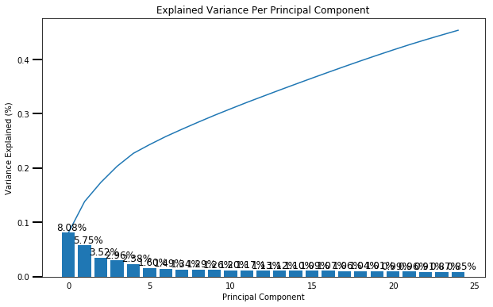

```python
scree_plot(pca1)
```

### Step 2.3: Interpret Principal Components

Now that we have our transformed principal components, it's a nice idea to check out the weight of each variable on the first few components to see if they can be interpreted in some fashion.

As a reminder, each principal component is a unit vector that points in the direction of highest variance (after accounting for the variance captured by earlier principal components). The further a weight is from zero, the more the principal component is in the direction of the corresponding feature. If two features have large weights of the same sign (both positive or both negative), then increases in one tend expect to be associated with increases in the other. To contrast, features with different signs can be expected to show a negative correlation: increases in one variable should result in a decrease in the other.

- To investigate the features, you should map each weight to their corresponding feature name, then sort the features according to weight. The most interesting features for each principal component, then, will be those at the beginning and end of the sorted list. Use the data dictionary document to help you understand these most prominent features, their relationships, and what a positive or negative value on the principal component might indicate.
- You should investigate and interpret feature associations from the first three principal components in this substep. To help facilitate this, you should write a function that you can call at any time to print the sorted list of feature weights, for the *i*-th principal component. This might come in handy in the next step of the project, when you interpret the tendencies of the discovered clusters.

```python
def pca_weights (item, df):
    sorted_df = df.sort_values(df.index [item], axis=1)

    return sorted_df.iloc [[item]]
```

```python
df_comp=pd.DataFrame (pca1.components_)
df_comp.columns = azdias6.columns
display (df_comp)
```

|  | ALTERSKATEGORIE_GROB | ANREDE_KZ | FINANZ_MINIMALIST | FINANZ_SPARER | FINANZ_VORSORGER | FINANZ_ANLEGER | FINANZ_UNAUFFAELLIGER | FINANZ_HAUSBAUER | GREEN_AVANTGARDE | HEALTH_TYP | ... | CAMEO_DEU_2015_8D | CAMEO_DEU_2015_9A | CAMEO_DEU_2015_9B | CAMEO_DEU_2015_9C | CAMEO_DEU_2015_9D | CAMEO_DEU_2015_9E | PRAEGENDE_JUGENDJAHRE_AM | PRAEGENDE_JUGENDJAHRE_DC | CAMEO_INTL_2015_LS | CAMEO_INTL_2015_WL |
| --- | --- | --- | --- | --- | --- | --- | --- | --- | --- | --- | --- | --- | --- | --- | --- | --- | --- | --- | --- | --- | --- |
| 0 | -0.076342 | 0.014526 | -0.185813 | 0.106460 | -0.076784 | 0.048357 | 0.045274 | 0.148992 | -0.104021 | 0.022441 | ... | 0.025772 | 0.036509 | 0.056090 | 0.057142 | 0.056649 | 0.017754 | -0.087818 | 0.063726 | -0.106810 | 0.181407 |
| 1 | 0.235794 | 0.038300 | 0.095241 | -0.230332 | 0.221279 | -0.204025 | -0.215113 | 0.080367 | -0.004332 | -0.052252 | ... | 0.033429 | -0.008563 | -0.000218 | 0.003989 | 0.009831 | 0.038150 | 0.001726 | -0.240769 | 0.017099 | 0.047863 |
| 2 | 0.016670 | -0.346689 | 0.129779 | -0.057061 | 0.047979 | -0.152785 | -0.048784 | -0.060241 | 0.067303 | -0.006475 | ... | 0.000766 | -0.003876 | 0.012680 | 0.025055 | 0.011639 | -0.001023 | 0.052243 | -0.050296 | -0.015448 | 0.019441 |
| 3 | 0.007357 | 0.055021 | -0.005662 | -0.005710 | 0.011684 | -0.048983 | -0.001173 | 0.004950 | 0.168124 | -0.012468 | ... | 0.002139 | 0.023215 | 0.011780 | 0.016426 | 0.012130 | 0.006433 | 0.159875 | 0.005649 | -0.010396 | 0.018544 |
| 4 | 0.049724 | -0.057754 | 0.017835 | -0.028603 | 0.038716 | 0.050359 | -0.111825 | 0.014194 | -0.271059 | 0.003243 | ... | 0.034562 | 0.050315 | 0.031670 | 0.011992 | 0.020424 | -0.004848 | -0.268360 | -0.034593 | -0.071213 | 0.137839 |
| 5 | -0.003965 | 0.002381 | -0.138904 | 0.015143 | 0.032654 | 0.033505 | 0.010688 | 0.213742 | -0.020112 | -0.067513 | ... | 0.009563 | -0.034838 | -0.063794 | -0.055972 | -0.062573 | 0.019943 | -0.000778 | -0.033161 | 0.066642 | 0.013479 |
| 6 | 0.019277 | 0.006806 | 0.057131 | -0.019160 | -0.034082 | -0.021996 | -0.013558 | -0.105221 | -0.062291 | 0.049033 | ... | -0.056962 | -0.014782 | 0.023668 | 0.046185 | 0.006942 | 0.063223 | -0.064382 | 0.027864 | -0.065589 | -0.057390 |
| 7 | -0.012798 | 0.014002 | -0.034687 | 0.041560 | 0.000393 | 0.062470 | 0.001131 | 0.042730 | 0.021695 | -0.007868 | ... | -0.042216 | 0.075819 | 0.088568 | 0.102556 | 0.114719 | 0.042716 | 0.046845 | -0.011328 | -0.091672 | -0.042493 |
| 8 | 0.045114 | -0.025679 | 0.011602 | -0.016956 | 0.084069 | -0.084265 | 0.064377 | -0.079744 | -0.021851 | 0.029016 | ... | -0.089311 | 0.019511 | -0.028732 | 0.011900 | 0.046949 | -0.020834 | -0.019926 | -0.003217 | -0.249035 | 0.056325 |
| 9 | 0.000432 | -0.006176 | -0.060412 | 0.010329 | 0.061892 | 0.009935 | 0.021823 | 0.082238 | -0.043477 | -0.027928 | ... | -0.014837 | 0.066345 | 0.025517 | 0.041171 | 0.055273 | 0.059103 | -0.021338 | -0.034893 | -0.004933 | -0.057459 |
| 10 | 0.079922 | -0.043332 | -0.070690 | 0.028230 | -0.013716 | 0.056091 | -0.009979 | 0.064557 | 0.055000 | -0.042034 | ... | 0.038643 | 0.068838 | 0.078579 | 0.046218 | 0.010676 | 0.110669 | 0.061555 | 0.029405 | 0.076633 | -0.045603 |
| 11 | -0.022209 | 0.005272 | -0.012764 | -0.011580 | 0.030929 | -0.050424 | 0.031041 | -0.008572 | -0.082124 | -0.026587 | ... | 0.035975 | 0.024524 | -0.033249 | 0.006524 | 0.004067 | 0.073085 | -0.077298 | -0.020077 | 0.289645 | -0.059150 |
| 12 | -0.062643 | 0.021139 | 0.025349 | -0.048689 | 0.035356 | -0.072130 | -0.041268 | -0.005324 | -0.043045 | 0.057729 | ... | -0.111073 | 0.094844 | 0.098811 | 0.123213 | 0.127400 | 0.049525 | -0.057150 | -0.026272 | 0.017851 | -0.091938 |
| 13 | -0.016925 | 0.020166 | -0.020688 | -0.008294 | -0.009359 | -0.016376 | 0.026485 | 0.020761 | -0.040639 | -0.035979 | ... | 0.090149 | -0.066872 | -0.067425 | -0.060777 | -0.063474 | -0.022826 | -0.043296 | -0.000784 | -0.039493 | -0.070264 |
| 14 | -0.020810 | 0.002340 | 0.022123 | -0.033415 | 0.006527 | -0.017377 | -0.073113 | -0.025134 | -0.019397 | 0.065687 | ... | -0.023934 | 0.018701 | 0.020445 | 0.012298 | -0.008693 | -0.007144 | -0.037332 | -0.007305 | -0.026575 | 0.000462 |
| 15 | -0.007628 | -0.007216 | -0.001433 | 0.002731 | -0.017698 | 0.026738 | -0.041868 | -0.010406 | 0.016632 | 0.077507 | ... | -0.067986 | 0.034951 | 0.034600 | 0.034543 | 0.039130 | -0.023935 | 0.014120 | 0.013059 | 0.003183 | 0.004205 |
| 16 | 0.060202 | -0.009590 | -0.047590 | 0.074401 | -0.042108 | 0.056221 | 0.151568 | 0.027310 | 0.023436 | -0.129374 | ... | -0.069753 | -0.009706 | 0.003335 | 0.021828 | 0.075979 | 0.008735 | 0.054471 | 0.031530 | -0.062618 | 0.067649 |
| 17 | -0.008025 | -0.017150 | 0.017840 | -0.031686 | 0.026977 | -0.019939 | -0.073546 | 0.003540 | -0.019627 | 0.019852 | ... | -0.003931 | 0.011525 | 0.004174 | -0.021882 | -0.032018 | -0.030150 | -0.035433 | -0.023160 | -0.003318 | -0.017319 |
| 18 | -0.013723 | 0.025865 | -0.041496 | 0.011341 | -0.047242 | -0.013032 | 0.064046 | 0.026677 | -0.076952 | -0.108581 | ... | 0.055842 | -0.077207 | -0.091421 | -0.083921 | -0.121297 | 0.056728 | -0.083800 | 0.013165 | 0.099857 | -0.059121 |
| 19 | 0.015519 | 0.002548 | 0.003369 | 0.004952 | -0.011005 | 0.053949 | -0.068679 | 0.008512 | 0.023014 | 0.018377 | ... | 0.004756 | 0.096443 | 0.125320 | 0.026330 | 0.034353 | -0.021420 | 0.020412 | 0.001612 | -0.136984 | 0.105061 |
| 20 | 0.004528 | -0.024327 | -0.036961 | 0.004608 | 0.078022 | -0.000730 | 0.032719 | 0.070030 | -0.098530 | 0.011436 | ... | 0.000968 | -0.000087 | -0.072977 | 0.001355 | 0.037241 | -0.035603 | -0.080187 | -0.030501 | 0.022513 | -0.129256 |
| 21 | 0.072685 | -0.002588 | -0.008287 | 0.024521 | -0.070343 | 0.009699 | 0.116858 | -0.016521 | -0.010892 | -0.108708 | ... | -0.027240 | 0.087134 | 0.111509 | 0.083780 | 0.183964 | 0.006764 | -0.005579 | 0.032986 | -0.124620 | -0.002735 |
| 22 | 0.041898 | -0.078837 | -0.019360 | 0.084911 | -0.086833 | 0.055147 | 0.030656 | -0.092521 | -0.050792 | 0.274188 | ... | -0.043757 | -0.073228 | 0.018627 | 0.034646 | -0.047305 | -0.044895 | -0.037501 | 0.109324 | 0.003898 | -0.087182 |
| 23 | 0.001934 | -0.022515 | -0.025283 | 0.005817 | -0.039469 | 0.030930 | -0.032383 | 0.028089 | -0.008717 | 0.029019 | ... | 0.146065 | 0.007998 | 0.025148 | -0.044467 | -0.050874 | 0.007976 | -0.036809 | 0.015732 | 0.250010 | -0.087251 |
| 24 | -0.059552 | 0.022838 | 0.025891 | -0.036662 | 0.073658 | 0.026081 | -0.070940 | 0.023260 | -0.003646 | -0.069879 | ... | 0.043592 | -0.049136 | -0.043873 | -0.017464 | 0.044629 | 0.057111 | 0.054453 | -0.060492 | 0.017693 | 0.034995 |

25 rows × 194 columns

```python
# Map weights for the first principal component to corresponding feature names
# and then print the linked values, sorted by weight.
# HINT: Try defining a function here or in a new cell that you can reuse in the
# other cells.

display( pca_weights(1,df_comp) )
```

|  | PRAEGENDE_JUGENDJAHRE_DC | FINANZ_SPARER | FINANZ_UNAUFFAELLIGER | SEMIO_REL | SEMIO_TRADV | SEMIO_PFLICHT | FINANZ_ANLEGER | SEMIO_RAT | SEMIO_KULT | ONLINE_AFFINITAET | ... | FINANZTYP_2.0 | FINANZTYP_5.0 | CJT_GESAMTTYP_2.0 | W_KEIT_KIND_HH | RETOURTYP_BK_S | SEMIO_LUST | SEMIO_ERL | ZABEOTYP_3.0 | FINANZ_VORSORGER | ALTERSKATEGORIE_GROB |
| --- | --- | --- | --- | --- | --- | --- | --- | --- | --- | --- | --- | --- | --- | --- | --- | --- | --- | --- | --- | --- | --- |
| 1 | -0.240769 | -0.230332 | -0.215113 | -0.215054 | -0.210025 | -0.206994 | -0.204025 | -0.170467 | -0.165771 | -0.163468 | ... | 0.095695 | 0.096665 | 0.110761 | 0.131404 | 0.155644 | 0.165941 | 0.181342 | 0.200465 | 0.221279 | 0.235794 |

1 rows × 194 columns

```python
# Map weights for the second principal component to corresponding feature names
# and then print the linked values, sorted by weight.

display( pca_weights(2,df_comp) )
```

|  | ANREDE_KZ | SEMIO_KAEM | SEMIO_DOM | SEMIO_KRIT | SEMIO_ERL | SEMIO_RAT | FINANZ_ANLEGER | SHOPPER_TYP_2.0 | FINANZTYP_1.0 | LP_STATUS_FEIN_2.0 | ... | SEMIO_MAT | SEMIO_REL | ZABEOTYP_1.0 | SHOPPER_TYP_0.0 | FINANZ_MINIMALIST | FINANZTYP_5.0 | SEMIO_KULT | SEMIO_SOZ | SEMIO_FAM | SEMIO_VERT |
| --- | --- | --- | --- | --- | --- | --- | --- | --- | --- | --- | --- | --- | --- | --- | --- | --- | --- | --- | --- | --- | --- |
| 2 | -0.346689 | -0.317667 | -0.286114 | -0.267528 | -0.208541 | -0.156358 | -0.152785 | -0.107623 | -0.101773 | -0.080701 | ... | 0.089225 | 0.111961 | 0.115216 | 0.123816 | 0.129779 | 0.133599 | 0.25221 | 0.257694 | 0.261102 | 0.320626 |

1 rows × 194 columns

```python
# Map weights for the third principal component to corresponding feature names
# and then print the linked values, sorted by weight.

display( pca_weights(3,df_comp) )
```

|  | LP_FAMILIE_GROB_1.0 | LP_FAMILIE_FEIN_1.0 | W_KEIT_KIND_HH | INNENSTADT | BALLRAUM | LP_STATUS_GROB_4.0 | LP_STATUS_FEIN_4.0 | LP_STATUS_FEIN_9.0 | KONSUMNAEHE | PLZ8_ANTG1 | ... | LP_STATUS_FEIN_10.0 | PRAEGENDE_JUGENDJAHRE_AM | GREEN_AVANTGARDE | EWDICHTE | ORTSGR_KLS9 | LP_FAMILIE_FEIN_10.0 | LP_FAMILIE_GROB_5.0 | ANZ_PERSONEN | LP_LEBENSPHASE_FEIN | LP_LEBENSPHASE_GROB |
| --- | --- | --- | --- | --- | --- | --- | --- | --- | --- | --- | --- | --- | --- | --- | --- | --- | --- | --- | --- | --- | --- |
| 3 | -0.268896 | -0.268896 | -0.161764 | -0.149871 | -0.140829 | -0.132082 | -0.127449 | -0.112001 | -0.103036 | -0.101469 | ... | 0.147091 | 0.159875 | 0.168124 | 0.181415 | 0.181778 | 0.183965 | 0.240517 | 0.242977 | 0.265302 | 0.270919 |

1 rows × 194 columns

### Discussion 2.3: Interpret Principal Components

(Double-click this cell and replace this text with your own text, reporting your observations from detailed investigation of the first few principal components generated. Can we interpret positive and negative values from them in a meaningful way?)

Principal component #1.

Prominent features are:

Negative: MOBI_REGIO (Movement patterns - region feature), KBA05_ANTG1 (Number of 1-2 family houses in the microcell), PLZ8_ANTG1 (Number of 1-2 family houses in the PLZ8 region), FINANZ_MINIMALIST (MINIMALIST: low financial interest)

Positive: LP_STATUS_GROB_1.0 (Social status, rough scale), HH_EINKOMMEN_SCORE (Estimated household net income), PLZ8_ANTG3 (Number of 6-10 family houses in the PLZ8 region), CAMEO_INTL_2015_WL (Wealth of household).

From above I can presume that such factors as the most crucial such as movement level in the region, number of 1-2 houses in the microcell and region, social status, income, number 6-10 family houses in the region and wealth. It appears that the increases in 1-2 family houses will lead to decreases 6-10 family houses which is logical and confirmed by PCA. Increases in number of 1-2 family in microcell affects in increases of 1-2 family in the region.

Principal component #2.

Prominent features are:

Negative: PRAEGENDE_JUGENDJAHRE_DC (person's youth in decades), FINANZ_SPARER (financial typology - money saver), SEMIO_REL (religious)

Positive: ALTERSKATEGORIE_GROB (Estimated age), FINANZ_VORSORGER (financial typology - be prepared), ZABEOTYP_3 (Energy consumption typology).

From above I can presume that such factors as the most crucial such as youth in decades/age, financial typology, religious factor and energey consumption typology. It is also visible here that the more increases money saver then be prepared decreases as they are negatively correlated between each other. I can also conclude that religious factor is in accordance with money saver typology, from life experience I can also confirm that major religious are not supporting money wasting.

Principal component #3.

Prominent features are:

Negative: ANREDE_KZ (Gender), SEMIO_KAEM (personal typology -combative attitude), SEMIO_DOM (personal typology -dominant-minded)

Positive: SEMIO_VERT (personal typology - dreamful), SEMIO_SOZ (personal typology - socially-minded), SEMIO_FAM (personal typology- family-minded).

Both gender and personal typology closely related to each other being characteristic of a human. From the same negative direction we can see their correlation: gender factor, combative-dominant are in syncronization where factors increase together. From the other hand antagonists of combative and dominant-minded are dreamful, socially-minded and family-minded which also confirmed by PCA component.

## Step 3: Clustering

### Step 3.1: Apply Clustering to General Population

You've assessed and cleaned the demographics data, then scaled and transformed them. Now, it's time to see how the data clusters in the principal components space. In this substep, you will apply k-means clustering to the dataset and use the average within-cluster distances from each point to their assigned cluster's centroid to decide on a number of clusters to keep.

- Use sklearn's KMeans class to perform k-means clustering on the PCA-transformed data.
- Then, compute the average difference from each point to its assigned cluster's center. **Hint**: The KMeans object's `.score()` method might be useful here, but note that in sklearn, scores tend to be defined so that larger is better. Try applying it to a small, toy dataset, or use an internet search to help your understanding.
- Perform the above two steps for a number of different cluster counts. You can then see how the average distance decreases with an increasing number of clusters. However, each additional cluster provides a smaller net benefit. Use this fact to select a final number of clusters in which to group the data. **Warning**: because of the large size of the dataset, it can take a long time for the algorithm to resolve. The more clusters to fit, the longer the algorithm will take. You should test for cluster counts through at least 10 clusters to get the full picture, but you shouldn't need to test for a number of clusters above about 30.
- Once you've selected a final number of clusters to use, re-fit a KMeans instance to perform the clustering operation. Make sure that you also obtain the cluster assignments for the general demographics data, since you'll be using them in the final Step 3.3.

```python
def get_kmeans_score(data, center):
    '''
    returns the kmeans score regarding SSE for points to centers
    INPUT:
        data - the dataset you want to fit kmeans to
        center - the number of centers you want (the k value)
    OUTPUT:
        score - the SSE score for the kmeans model fit to the data
    '''
    #instantiate kmeans
    kmeans = KMeans(n_clusters=center)

    # Then fit the model to your data using the fit method
    model = kmeans.fit(data)

    # Obtain a score related to the model fit
    score = np.abs(model.score(data)) #absolute value taken

    return score
```

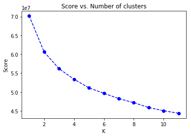

```python
# Over a number of different cluster counts...
scores = []
centers = list(range(1,12))

for center in centers:
    scores.append(get_kmeans_score(azdias6_pca1, center))

plt.plot(centers, scores, linestyle='--', marker='o', color='b');
plt.xlabel('K');
plt.ylabel('Score');
plt.title('Score vs. Number of clusters');
```

```python
# Re-fit the k-means model with the selected number of clusters and obtain
# cluster predictions for the general population demographics data.

kmeans = KMeans (n_clusters = 5)

model = kmeans.fit (azdias6_pca1) #fitting to the data

azdias_clust = model.predict (azdias6_pca1) #returning array of indeces for the cluster each sample belongs to.
```

### Discussion 3.1: Apply Clustering to General Population

(Double-click this cell and replace this text with your own text, reporting your findings and decisions regarding clustering. Into how many clusters have you decided to segment the population?)

I have prepaed a plot that reflects correlation between number of clusters and score (average distance to the from points of a cluster to cluster's centroid). Using elbow method I came to conclusion that 5 clusters should be a good decision since further from that score is not decreasing as much fast as looking into less number of clusters.

### Step 3.2: Apply All Steps to the Customer Data

Now that you have clusters and cluster centers for the general population, it's time to see how the customer data maps on to those clusters. Take care to not confuse this for re-fitting all of the models to the customer data. Instead, you're going to use the fits from the general population to clean, transform, and cluster the customer data. In the last step of the project, you will interpret how the general population fits apply to the customer data.

- Don't forget when loading in the customers data, that it is semicolon (`;`) delimited.
- Apply the same feature wrangling, selection, and engineering steps to the customer demographics using the `clean_data()` function you created earlier. (You can assume that the customer demographics data has similar meaning behind missing data patterns as the general demographics data.)
- Use the sklearn objects from the general demographics data, and apply their transformations to the customers data. That is, you should not be using a `.fit()` or `.fit_transform()` method to re-fit the old objects, nor should you be creating new sklearn objects! Carry the data through the feature scaling, PCA, and clustering steps, obtaining cluster assignments for all of the data in the customer demographics data.

```python
# Load in the customer demographics data.
customers = pd.read_csv ('Udacity_CUSTOMERS_Subset.csv', sep = ';')
```

```python
(customers.head (n=5))
```

|  | AGER_TYP | ALTERSKATEGORIE_GROB | ANREDE_KZ | CJT_GESAMTTYP | FINANZ_MINIMALIST | FINANZ_SPARER | FINANZ_VORSORGER | FINANZ_ANLEGER | FINANZ_UNAUFFAELLIGER | FINANZ_HAUSBAUER | ... | PLZ8_ANTG1 | PLZ8_ANTG2 | PLZ8_ANTG3 | PLZ8_ANTG4 | PLZ8_BAUMAX | PLZ8_HHZ | PLZ8_GBZ | ARBEIT | ORTSGR_KLS9 | RELAT_AB |
| --- | --- | --- | --- | --- | --- | --- | --- | --- | --- | --- | --- | --- | --- | --- | --- | --- | --- | --- | --- | --- | --- |
| 0 | 2 | 4 | 1 | 5.0 | 5 | 1 | 5 | 1 | 2 | 2 | ... | 3.0 | 3.0 | 1.0 | 0.0 | 1.0 | 5.0 | 5.0 | 1.0 | 2.0 | 1.0 |
| 1 | -1 | 4 | 1 | NaN | 5 | 1 | 5 | 1 | 3 | 2 | ... | NaN | NaN | NaN | NaN | NaN | NaN | NaN | NaN | NaN | NaN |
| 2 | -1 | 4 | 2 | 2.0 | 5 | 1 | 5 | 1 | 4 | 4 | ... | 2.0 | 3.0 | 3.0 | 1.0 | 3.0 | 3.0 | 2.0 | 3.0 | 5.0 | 3.0 |
| 3 | 1 | 4 | 1 | 2.0 | 5 | 1 | 5 | 2 | 1 | 2 | ... | 3.0 | 2.0 | 1.0 | 0.0 | 1.0 | 3.0 | 4.0 | 1.0 | 3.0 | 1.0 |
| 4 | -1 | 3 | 1 | 6.0 | 3 | 1 | 4 | 4 | 5 | 2 | ... | 2.0 | 4.0 | 2.0 | 1.0 | 2.0 | 3.0 | 3.0 | 3.0 | 5.0 | 1.0 |

5 rows × 85 columns

```python
# Apply preprocessing, feature transformation, and clustering from the general
# demographics onto the customer data, obtaining cluster predictions for the
# customer demographics data.

customers_cl, cust_dropped_rows, rows_number, cust_index, cust_df_out = clean_data(customers)
```

```
Shape before binary encoding (141650, 79)
Shape before one hot encoding (141650, 79)
Shape after one hot encoding (141650, 194)
Shape after mix value change (141650, 198)
Shape after dropping additional columns (141650, 194)
```

```python
display(customers_cl.head(n=5))
```

|  | ALTERSKATEGORIE_GROB | ANREDE_KZ | FINANZ_MINIMALIST | FINANZ_SPARER | FINANZ_VORSORGER | FINANZ_ANLEGER | FINANZ_UNAUFFAELLIGER | FINANZ_HAUSBAUER | GREEN_AVANTGARDE | HEALTH_TYP | ... | CAMEO_DEU_2015_8D | CAMEO_DEU_2015_9A | CAMEO_DEU_2015_9B | CAMEO_DEU_2015_9C | CAMEO_DEU_2015_9D | CAMEO_DEU_2015_9E | PRAEGENDE_JUGENDJAHRE_AM | PRAEGENDE_JUGENDJAHRE_DC | CAMEO_INTL_2015_LS | CAMEO_INTL_2015_WL |
| --- | --- | --- | --- | --- | --- | --- | --- | --- | --- | --- | --- | --- | --- | --- | --- | --- | --- | --- | --- | --- | --- |
| 0 | 4 | 1 | 5 | 1 | 5 | 1 | 2 | 2 | 1 | 1.0 | ... | 0 | 0 | 0 | 0 | 0 | 0 | 1.0 | 50.0 | 3.0 | 1.0 |
| 2 | 4 | 2 | 5 | 1 | 5 | 1 | 4 | 4 | 1 | 2.0 | ... | 0 | 0 | 0 | 0 | 0 | 0 | 1.0 | 50.0 | 4.0 | 3.0 |
| 3 | 4 | 1 | 5 | 1 | 5 | 2 | 1 | 2 | 0 | 2.0 | ... | 0 | 0 | 0 | 0 | 0 | 0 | 0.0 | 40.0 | 4.0 | 2.0 |
| 4 | 3 | 1 | 3 | 1 | 4 | 4 | 5 | 2 | 0 | 3.0 | ... | 0 | 0 | 0 | 0 | 0 | 0 | 0.0 | 70.0 | 1.0 | 4.0 |
| 5 | 3 | 1 | 5 | 1 | 5 | 1 | 2 | 3 | 1 | 3.0 | ... | 0 | 0 | 0 | 0 | 0 | 0 | 1.0 | 50.0 | 4.0 | 3.0 |

5 rows × 194 columns

```python
#features scaling

customers_cl5 = pd.DataFrame (scaler.fit_transform (customers_cl))
#customers_cl5 = pd.DataFrame (scaler.transform (customers_cl))
customers_cl5.columns = customers_cl.columns #restoring column names
customers_cl5.index = customers_cl.index #restoring indeces
```

```python
#PCA for customer data
customer_cl5_pca = pca1.transform (customers_cl5)
```

```python
# Re-fit the k-means model with the selected number of clusters and obtain
# cluster predictions for the general population demographics data.

customers_clust = model.predict (customer_cl5_pca) #returning array of indeces for the cluster each sample belongs to.

#display (pd.DataFrame (customers_clust))
```

### Step 3.3: Compare Customer Data to Demographics Data

At this point, you have clustered data based on demographics of the general population of Germany, and seen how the customer data for a mail-order sales company maps onto those demographic clusters. In this final substep, you will compare the two cluster distributions to see where the strongest customer base for the company is.

Consider the proportion of persons in each cluster for the general population, and the proportions for the customers. If we think the company's customer base to be universal, then the cluster assignment proportions should be fairly similar between the two. If there are only particular segments of the population that are interested in the company's products, then we should see a mismatch from one to the other. If there is a higher proportion of persons in a cluster for the customer data compared to the general population (e.g. 5% of persons are assigned to a cluster for the general population, but 15% of the customer data is closest to that cluster's centroid) then that suggests the people in that cluster to be a target audience for the company. On the other hand, the proportion of the data in a cluster being larger in the general population than the customer data (e.g. only 2% of customers closest to a population centroid that captures 6% of the data) suggests that group of persons to be outside of the target demographics.

Take a look at the following points in this step:

- Compute the proportion of data points in each cluster for the general population and the customer data. Visualizations will be useful here: both for the individual dataset proportions, but also to visualize the ratios in cluster representation between groups. Seaborn's [`countplot()`](https://seaborn.pydata.org/generated/seaborn.countplot.html) or [`barplot()`](https://seaborn.pydata.org/generated/seaborn.barplot.html) function could be handy.
  - Recall the analysis you performed in step 1.1.3 of the project, where you separated out certain data points from the dataset if they had more than a specified threshold of missing values. If you found that this group was qualitatively different from the main bulk of the data, you should treat this as an additional data cluster in this analysis. Make sure that you account for the number of data points in this subset, for both the general population and customer datasets, when making your computations!
- Which cluster or clusters are overrepresented in the customer dataset compared to the general population? Select at least one such cluster and infer what kind of people might be represented by that cluster. Use the principal component interpretations from step 2.3 or look at additional components to help you make this inference. Alternatively, you can use the `.inverse_transform()` method of the PCA and StandardScaler objects to transform centroids back to the original data space and interpret the retrieved values directly.
- Perform a similar investigation for the underrepresented clusters. Which cluster or clusters are underrepresented in the customer dataset compared to the general population, and what kinds of people are typified by these clusters?

```
array([[<matplotlib.axes._subplots.AxesSubplot object at 0x7f951706bfd0>]], dtype=object)
```

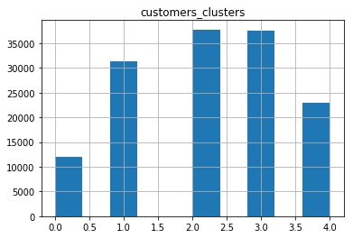

```python
# Compare the proportion of data in each cluster for the customer data to the
# proportion of data in each cluster for the general population.

cust_cldf = pd.DataFrame (customers_clust, columns = ['customers_clusters'])

cust_cldf.hist ()
```

```
array([[<matplotlib.axes._subplots.AxesSubplot object at 0x7f9517000e10>]], dtype=object)
```

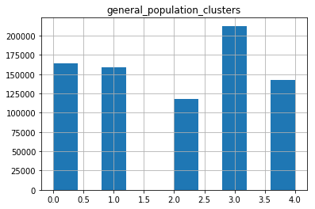

```python
azdias_cldf = pd.DataFrame (azdias_clust, columns = ['general_population_clusters'])

azdias_cldf.hist ()
```

```python
azdias_prop = pd.DataFrame (azdias_cldf.general_population_clusters.value_counts ())/ (azdias_new.shape [0]) * 100

#number of dropped rows where missing values were presented in more than 10 fields
azdias_drop_number = (azdias_new2 [ azdias_new2 ['missing_in_rows'] >10].shape [0])/ (azdias_new.shape [0]) * 100

print (azdias_drop_number)

#adding dropped rows as separate cluster
value_toadd = pd.Series ([azdias_drop_number], index = ['general_population_clusters'])
azdias_prop = azdias_prop.append (value_toadd, ignore_index=True)

azdias_prop.sort_index (inplace = True)
display (azdias_prop)

print (azdias_prop.sum ())
```

```
12.462453196233033
```

|  | general_population_clusters |
| --- | --- |
| 0 | 23.873652 |
| 1 | 18.450867 |
| 2 | 17.858533 |
| 3 | 16.000745 |
| 4 | 13.252717 |
| 5 | 12.462453 |

```
general_population_clusters    101.898968
dtype: float64
```

```python
customers_prop = pd.DataFrame (cust_cldf.customers_clusters.value_counts ())/ (rows_number) * 100

#adding dropped rows as separate cluster
additional_cluster = (cust_dropped_rows/ (rows_number)) * 100
print (additional_cluster)

value_toaddc = pd.Series ([additional_cluster], index = ['customers_clusters'])
customers_prop = customers_prop.append (value_toaddc, ignore_index=True)

customers_prop.sort_index (inplace = True)
display (customers_prop)

print (customers_prop.sum ())
```

```
26.089996451902408
```

|  | customers_clusters |
| --- | --- |
| 0 | 19.723770 |
| 1 | 19.586542 |
| 2 | 16.404212 |
| 3 | 11.951871 |
| 4 | 6.243608 |
| 5 | 26.089996 |

```
customers_clusters    100.0
dtype: float64
```

```python
#restoring indices for general population and applying them to clustered list, using the indeces
#we can investigate rows of the original dataset
azdias_clust_inv = pd.DataFrame (azdias_clust, columns = ['clusters'])
azdias_clust_inv.index = azdias6.index #restoring indeces
display (azdias_clust_inv.tail (n=10))
print (azdias_clust_inv.shape)
```

|  | clusters |
| --- | --- |
| 891211 | 3 |
| 891212 | 3 |
| 891213 | 2 |
| 891214 | 0 |
| 891215 | 0 |
| 891216 | 0 |
| 891217 | 3 |
| 891218 | 4 |
| 891219 | 0 |
| 891220 | 3 |

```
(797077, 1)
```

```python
#restoring indices for customer population and applying them to clustered list, using the indeces
#we can investigate rows of the original dataset
customers_clust_inv = pd.DataFrame (customers_clust, columns = ['clusters'])
customers_clust_inv.index = cust_index #restoring indeces
display (customers_clust_inv.tail (n=10))
print (customers_clust_inv.shape)
```

|  | clusters |
| --- | --- |
| 191642 | 3 |
| 191643 | 2 |
| 191644 | 3 |
| 191645 | 4 |
| 191646 | 0 |
| 191647 | 3 |
| 191648 | 1 |
| 191649 | 2 |
| 191650 | 3 |
| 191651 | 4 |

```
(141650, 1)
```